# Data Processing

[EcoTyper_Project, Data processing](https://github.com/sogolsahebi/EcoTyper_Project)

Nasim Bondar Sahebi

2024-11-01

## load libraries

```r
library(SummarizedExperiment)
library(MultiAssayExperiment)
library(dplyr)
library(knitr)
library(kableExtra)
library(tools)
library(ggplot2)
library(networkD3)
```

## Data Loading and Preparation

This section includes immunotherapy datasets curated in the BHK Lab, with sources available on [GitHub](https://github.com/bhklab/ClinSets/tree/main/data). The datasets are organized as follows:

- **All Data**: Stored in the `data_all` folder, containing `.rda` files for each cohort (e.g., `ICB_Braun__Kidney__PD-(L)1.rda`).
- **Data Stratified by Sex**: Stored in the `data_sex` folder, with datasets split by gender. Files for female and male data are indicated with `_F` and `_M` in the filename (e.g., `ICB_Gide__Melanoma__PD-(L)1__F.rda` for female data and `ICB_Gide__Melanoma__PD-(L)1__M.rda` for male data).

This section will list and display all `.rda` files from the `data_all` and `data_sex` directories, covering a total of 56 study cohorts.

```r
# Set base directory
Base_dir <- "~/BHK lab/EcoTyper_Project/"

# List .rda files in both directories
data_files <- list.files(path = file.path(Base_dir, "data_all"), pattern = "\\.rda$", full.names = TRUE)
data_sex_files <- list.files(path = file.path(Base_dir, "data_sex"), pattern = "\\.rda$", full.names = TRUE)

# Create a table of all studies
data_files_df <- data.frame(Files = basename(data_files))
kable(data_files_df, caption = "All studies", col.names = "Cohorts") %>%
  kable_styling(bootstrap_options = c("striped", "hover", "condensed"), full_width = F) %>%
  scroll_box(height = "400px")
```

All studies

| Cohorts |
| --- |
| ICB_Ascierto__Kidney__PD-(L)1.rda |
| ICB_Auslander__Melanoma__CTLA4.rda |
| ICB_Auslander__Melanoma__IO+combo.rda |
| ICB_Auslander__Melanoma__PD-(L)1.rda |
| ICB_Cloughesy__Brain__PD-(L)1.rda |
| ICB_Damrauer__Bladder__PD-(L)1.rda |
| ICB_Fehrenbacher__Lung__chemo.rda |
| ICB_Fehrenbacher__Lung__PD-(L)1.rda |
| ICB_Gide__Melanoma__PD-(L)1.rda |
| ICB_Hugo__Melanoma__PD-(L)1.rda |
| ICB_Hwang__Lung__PD-(L)1.rda |
| ICB_IMmotion150__Kidney__IO+targeted.rda |
| ICB_IMmotion150__Kidney__PD-(L)1.rda |
| ICB_IMmotion150__Kidney__targeted.rda |
| ICB_Jerby_Arnon__Melanoma__PD-(L)1.rda |
| ICB_Jung__Lung__PD-(L)1.rda |
| ICB_Kim__Gastric__PD-(L)1.rda |
| ICB_Limagne1__Lung__PD-(L)1.rda |
| ICB_Limagne2__Lung__PD-(L)1.rda |
| ICB_Liu__Melanoma__IO+combo.rda |
| ICB_Liu__Melanoma__PD-(L)1.rda |
| ICB_Mariathasan__Bladder__PD-(L)1.rda |
| ICB_Mariathasan__Kidney__PD-(L)1.rda |
| ICB_Mariathasan__Liver__PD-(L)1.rda |
| ICB_Mariathasan__Lung__PD-(L)1.rda |
| ICB_Mariathasan__Lymph_node__PD-(L)1.rda |
| ICB_Mariathasan__Unknown__PD-(L)1.rda |
| ICB_Mariathasan__Ureteral__PD-(L)1.rda |
| ICB_Miao1__Kidney__PD-(L)1.rda |
| ICB_Nathanson__Melanoma__CTLA4.rda |
| ICB_Padron__Pancreas__PD-(L)1.rda |
| ICB_Powles__Bladder__PD-(L)1.rda |
| ICB_Prat__HNC__PD-(L)1.rda |
| ICB_Prat__Lung__PD-(L)1.rda |
| ICB_Prat__Melanoma__PD-(L)1.rda |
| ICB_Puch__Melanoma__PD-(L)1.rda |
| ICB_Ravi__Lung__IO+chemo.rda |
| ICB_Ravi__Lung__IO+combo.rda |
| ICB_Ravi__Lung__PD-(L)1.rda |
| ICB_Riaz__Melanoma__IO+combo.rda |
| ICB_Riaz__Melanoma__PD-(L)1.rda |
| ICB_Rittmeyer__Lung__chemo.rda |
| ICB_Rittmeyer__Lung__PD-(L)1.rda |
| ICB_Roh__Melanoma__CTLA4.rda |
| ICB_Shiuan__Kidney__PD-(L)1.rda |
| ICB_Snyder__Ureteral__PD-(L)1.rda |
| ICB_Thibaudin__Colon__IO+chemo.rda |
| ICB_Van_Allen__Melanoma__CTLA4.rda |
| ICB_VanDenEnde__Esophageal__PD-(L)1.rda |
| ICB_Wolf__Breast__chemo.rda |
| ICB_Wolf__Breast__chemo+targeted.rda |
| ICB_Wolf__Breast__IO+chemo.rda |
| ICB_Wolf__Breast__targeted.rda |
| ICB_Wolf2__Breast__chemo.rda |
| ICB_Wolf2__Breast__IO+targeted.rda |
| ICB_Zhao__Brain__PD-(L)1.rda |

```r
# Initialize summary table
summary_table <- data.frame(Dataset = character(),
                            Cancer_Type = character(),
                            Clinical_Endpoints = character(),
                            Patients = integer(),
                            Treatments = character(),
                            stringsAsFactors = FALSE)

# Loop to extract information from each dataset
for (file in data_files) {
  dat_icb <- get(load(file))
  dataset_name <- sub("ICB_", "", basename(file))
  dataset_name <- sub("\\.rda$", "", dataset_name)
  clin <- data.frame(colData(dat_icb))

  # Extract details
  cancer_type <- paste(unique(clin$cancer_type), collapse = ", ")
  clinical_endpoints <- paste(ifelse(unique(clin$survival_type) == "None", "Response (R vs NR)",
                            unique(clin$survival_type)), collapse = ", ")

  patients <- dim(clin)[1]

  treatments <- paste(unique(clin$treatment), collapse = ", ")


  # Append to summary table
  summary_table <- rbind(summary_table, data.frame(Dataset = dataset_name,
                                                   Cancer_Type = cancer_type,
                                                   Clinical_Endpoints = clinical_endpoints,
                                                   Patients = patients,
                                                   Treatments = treatments,
                                                   stringsAsFactors = FALSE))

}

# Display summary table
kable(summary_table, caption = "Summary of Immunotherapy Datasets") %>%
  kable_styling(bootstrap_options = c("striped", "hover", "condensed"), full_width = F) %>%
  scroll_box(height = "400px")
```

Summary of Immunotherapy Datasets

| Dataset | Cancer_Type | Clinical_Endpoints | Patients | Treatments |
| --- | --- | --- | --- | --- |
| Ascierto__Kidney__PD-(L)1 | Kidney | Response (R vs NR) | 11 | PD-1/PD-L1 |
| Auslander__Melanoma__CTLA4 | Melanoma | Response (R vs NR) | 6 | CTLA4 |
| Auslander__Melanoma__IO+combo | Melanoma | Response (R vs NR) | 4 | IO+combo |
| Auslander__Melanoma__PD-(L)1 | Melanoma | Response (R vs NR) | 27 | PD-1/PD-L1 |
| Cloughesy__Brain__PD-(L)1 | Brain | PFS/OS | 28 | PD-1/PD-L1 |
| Damrauer__Bladder__PD-(L)1 | Bladder | PFS/OS | 90 | PD-1/PD-L1 |
| Fehrenbacher__Lung__chemo | Lung | PFS/OS | 97 | chemo |
| Fehrenbacher__Lung__PD-(L)1 | Lung | PFS/OS | 95 | PD-1/PD-L1 |
| Gide__Melanoma__PD-(L)1 | Melanoma | PFS/OS | 41 | PD-1/PD-L1 |
| Hugo__Melanoma__PD-(L)1 | Melanoma | OS | 27 | PD-1/PD-L1 |
| Hwang__Lung__PD-(L)1 | Lung | PFS/OS | 21 | PD-1/PD-L1 |
| IMmotion150__Kidney__IO+targeted | Kidney | Response (R vs NR) | 110 | IO+targeted |
| IMmotion150__Kidney__PD-(L)1 | Kidney | Response (R vs NR) | 107 | PD-1/PD-L1 |
| IMmotion150__Kidney__targeted | Kidney | Response (R vs NR) | 108 | targeted |
| Jerby_Arnon__Melanoma__PD-(L)1 | Melanoma | PFS | 112 | PD-1/PD-L1 |
| Jung__Lung__PD-(L)1 | Lung | PFS | 27 | PD-1/PD-L1 |
| Kim__Gastric__PD-(L)1 | Gastric | Response (R vs NR) | 45 | PD-1/PD-L1 |
| Limagne1__Lung__PD-(L)1 | Lung | NA | 70 | PD-1/PD-L1 |
| Limagne2__Lung__PD-(L)1 | Lung | NA | 26 | PD-1/PD-L1 |
| Liu__Melanoma__IO+combo | Melanoma | PFS/OS | 47 | IO+combo |
| Liu__Melanoma__PD-(L)1 | Melanoma | PFS/OS | 74 | PD-1/PD-L1 |
| Mariathasan__Bladder__PD-(L)1 | Bladder | OS | 195 | PD-1/PD-L1 |
| Mariathasan__Kidney__PD-(L)1 | Kidney | OS | 67 | PD-1/PD-L1 |
| Mariathasan__Liver__PD-(L)1 | Liver | OS | 5 | PD-1/PD-L1 |
| Mariathasan__Lung__PD-(L)1 | Lung | OS | 10 | PD-1/PD-L1 |
| Mariathasan__Lymph_node__PD-(L)1 | Lymph_node | OS | 26 | PD-1/PD-L1 |
| Mariathasan__Unknown__PD-(L)1 | Unknown | OS | 19 | PD-1/PD-L1 |
| Mariathasan__Ureteral__PD-(L)1 | Ureteral | OS | 26 | PD-1/PD-L1 |
| Miao1__Kidney__PD-(L)1 | Kidney | PFS/OS | 33 | PD-1/PD-L1 |
| Nathanson__Melanoma__CTLA4 | Melanoma | OS | 24 | CTLA4 |
| Padron__Pancreas__PD-(L)1 | Pancreas | PFS/OS | 45 | PD-1/PD-L1 |
| Powles__Bladder__PD-(L)1 | Bladder | Response (R vs NR) | 148 | PD-1/PD-L1 |
| Prat__HNC__PD-(L)1 | HNC | PFS | 5 | PD-1/PD-L1 |
| Prat__Lung__PD-(L)1 | Lung | PFS | 35 | PD-1/PD-L1 |
| Prat__Melanoma__PD-(L)1 | Melanoma | PFS | 25 | PD-1/PD-L1 |
| Puch__Melanoma__PD-(L)1 | Melanoma | Response (R vs NR) | 55 | PD-1/PD-L1 |
| Ravi__Lung__IO+chemo | Lung | PFS/OS | 2 | IO+chemo |
| Ravi__Lung__IO+combo | Lung | PFS/OS | 16 | IO+combo |
| Ravi__Lung__PD-(L)1 | Lung | PFS/OS | 130 | PD-1/PD-L1 |
| Riaz__Melanoma__IO+combo | Melanoma | OS | 23 | IO+combo |
| Riaz__Melanoma__PD-(L)1 | Melanoma | OS | 23 | PD-1/PD-L1 |
| Rittmeyer__Lung__chemo | Lung | PFS/OS | 355 | chemo |
| Rittmeyer__Lung__PD-(L)1 | Lung | PFS/OS | 344 | PD-1/PD-L1 |
| Roh__Melanoma__CTLA4 | Melanoma | OS | 16 | CTLA4 |
| Shiuan__Kidney__PD-(L)1 | Kidney | Response (R vs NR) | 15 | PD-1/PD-L1 |
| Snyder__Ureteral__PD-(L)1 | Ureteral | PFS/OS | 25 | PD-1/PD-L1 |
| Thibaudin__Colon__IO+chemo | Colon | PFS/OS | 34 | IO+chemo |
| Van_Allen__Melanoma__CTLA4 | Melanoma | PFS/OS | 42 | CTLA4 |
| VanDenEnde__Esophageal__PD-(L)1 | Esophageal | Response (R vs NR) | 35 | PD-1/PD-L1 |
| Wolf__Breast__chemo | Breast | Response (R vs NR) | 179 | chemo |
| Wolf__Breast__chemo+targeted | Breast | Response (R vs NR) | 687 | chemo+targeted |
| Wolf__Breast__IO+chemo | Breast | Response (R vs NR) | 69 | IO+chemo |
| Wolf__Breast__targeted | Breast | Response (R vs NR) | 52 | targeted |
| Wolf2__Breast__chemo | Breast | Response (R vs NR) | 34 | chemo |
| Wolf2__Breast__IO+targeted | Breast | Response (R vs NR) | 71 | IO+targeted |
| Zhao__Brain__PD-(L)1 | Brain | PFS/OS | 17 | PD-1/PD-L1 |

```r
#write.csv(summary_table, file = file.path(Base_dir, "outputs/Dataprocessing_outputs", "Summary_of_Each_Dataset_IO_Datasets.csv"), row.names = TRUE)
```

## Combine all Datasets

This section loads and combines clinical datasets from the `data` and `data_sex` directories. Key steps include:

- Listing `.rda` files from both directories.
- Extracting and merging clinical data based on common columns.
- Creating unique study and patient identifiers.
- Displaying combined clinical data in tables.

The final datasets are saved as `.rds` files for future use.

```r
# List .rda files in both directories
data_files <- list.files(path = file.path(Base_dir, "data_all"), pattern = "\\.rda$", full.names = TRUE)
data_sex_files <- list.files(path = file.path(Base_dir, "data_sex"), pattern = "\\.rda$", full.names = TRUE)

# Initialize lists for storing column names and clin dataframes for data_files
column_list <- list()
clin_list <- list()

for (data_path in data_files) {
    obj <- load(data_path)
    se <- get(obj)

    clin <- as.data.frame(colData(se))

    # Set row names with base name and index
    base_name <- tools::file_path_sans_ext(basename(data_path))
    rownames(clin) <- paste0(base_name, "_", seq_len(nrow(clin)))

    column_list[[data_path]] <- colnames(clin)  # Store column names
    clin_list[[data_path]] <- clin  # Store clinical data
}

# Identify common columns across all datasets
common_columns <- Reduce(intersect, column_list)

# Bind all clin dataframes using the common columns
combined_clin <- do.call(rbind, lapply(clin_list, function(clin) {
    clin <- data.frame(clin)
    clin[, common_columns, drop = FALSE]  # Subset to common columns
}))

combined_clin <- do.call(rbind, lapply(clin_list, function(clin) data.frame(clin)[, common_columns, drop = FALSE]))

# Create study and patient identifiers
combined_clin$study <- gsub("\\..*","", basename(rownames(combined_clin)))
combined_clin$study_patient <- paste0(combined_clin$study, "_", combined_clin$patientid)
rownames(combined_clin) <- combined_clin$study_patient

# Repeat for data_sex_files
data_sex_files_df <- data.frame(Files = basename(data_sex_files)) # List all data_sex .rda files

# Initialize lists for storing column names and clin dataframes for data_sex
column_sex_list <- list()
clin_sex_list <- list()

column_sex_list <- list()  # Initialize list for column names
clin_sex_list <- list()    # Initialize list for clinical data

for (data_sex_path in data_sex_files) {
    obj <- load(data_sex_path )
    clin_sex <- data.frame(colData(get(obj)))

    # Set row names with base name and index
    base_name <- tools::file_path_sans_ext(basename(data_sex_path))
    rownames(clin_sex) <- paste0(base_name, "_", seq_len(nrow(clin_sex)))

    column_sex_list[[data_sex_path ]] <- colnames(clin_sex)  # Store column names
    clin_sex_list[[data_sex_path]] <- clin_sex  # Store clinical data
}

# Identify common columns across all data_sex datasets
common_sex_columns <- Reduce(intersect, column_sex_list)

# Fully flatten clin_sex_list and bind using common columns
combined_clin_sex <- do.call(rbind, lapply(clin_sex_list, function(clin_sex) {
    #clin_sex <- as.data.frame(clin_sex)
    clin_sex[, common_sex_columns, drop = FALSE]
}))

# Save as csv files
# write.csv(combined_clin, file = file.path(Base_dir, "outputs/Dataprocessing_outputs", "combined_clin_before_exclusion.csv"), row.names = TRUE)

#write.csv(combined_clin_sex, file = file.path(Base_dir, "outputs/Dataprocessing_outputs", "combined_clin_sex_before_exclusion.csv"), row.names = TRUE)

# Create study and patient identifiers for data_sex
combined_clin_sex <- combined_clin_sex[!is.na(combined_clin_sex$patientid), ]
combined_clin_sex$study <- gsub("\\..*","", basename(rownames(combined_clin_sex)))
combined_clin_sex$study_patient <- paste0(combined_clin_sex$study, "_", combined_clin_sex$patientid)
rownames(combined_clin_sex) <- combined_clin_sex$study_patient

# Display the combined_clin table with scrolling enabled
kable(head(combined_clin), caption = "Summary of Combined Clinical Data (Data Directory)",
      col.names = colnames(combined_clin), format = "html") %>%
  kable_styling(bootstrap_options = c("striped", "hover", "condensed"), full_width = F) %>%
  scroll_box(height = "400px")
```

Summary of Combined Clinical Data (Data Directory)

|  | patientid | sex | age | cancer_type | histo | tissueid | treatmentid | stage | response.other.info | recist | response | treatment | dna | rna | survival_time_pfs | event_occurred_pfs | survival_time_os | event_occurred_os | survival_unit | survival_type | TMB_raw | nsTMB_raw | indel_TMB_raw | indel_nsTMB_raw | TMB_perMb | nsTMB_perMb | indel_TMB_perMb | indel_nsTMB_perMb | CIN | … |
| --- | --- | --- | --- | --- | --- | --- | --- | --- | --- | --- | --- | --- | --- | --- | --- | --- | --- | --- | --- | --- | --- | --- | --- | --- | --- | --- | --- | --- | --- | --- |
| ICB_Ascierto__Kidney__PD-(L)1_GSM1648114 | GSM1648114 | F | NA | Kidney | NA | Kidney | PD-1/PD-L1 | NA | NR | NA | NR | PD-1/PD-L1 | NA | microarray | NA | NA | NA | NA | month | None | NA | NA | NA | NA | NA | NA | NA | NA | NA | … |
| ICB_Ascierto__Kidney__PD-(L)1_GSM1648115 | GSM1648115 | M | NA | Kidney | NA | Kidney | PD-1/PD-L1 | NA | NR | NA | NR | PD-1/PD-L1 | NA | microarray | NA | NA | NA | NA | month | None | NA | NA | NA | NA | NA | NA | NA | NA | NA | … |
| ICB_Ascierto__Kidney__PD-(L)1_GSM1648116 | GSM1648116 | F | NA | Kidney | NA | Kidney | PD-1/PD-L1 | NA | NR | NA | NR | PD-1/PD-L1 | NA | microarray | NA | NA | NA | NA | month | None | NA | NA | NA | NA | NA | NA | NA | NA | NA | … |
| ICB_Ascierto__Kidney__PD-(L)1_GSM1648117 | GSM1648117 | M | NA | Kidney | NA | Kidney | PD-1/PD-L1 | NA | NR | NA | NR | PD-1/PD-L1 | NA | microarray | NA | NA | NA | NA | month | None | NA | NA | NA | NA | NA | NA | NA | NA | NA | … |
| ICB_Ascierto__Kidney__PD-(L)1_GSM1648118 | GSM1648118 | M | NA | Kidney | NA | Kidney | PD-1/PD-L1 | NA | NR | NA | NR | PD-1/PD-L1 | NA | microarray | NA | NA | NA | NA | month | None | NA | NA | NA | NA | NA | NA | NA | NA | NA | … |
| ICB_Ascierto__Kidney__PD-(L)1_GSM1648119 | GSM1648119 | M | NA | Kidney | NA | Kidney | PD-1/PD-L1 | NA | NR | NA | NR | PD-1/PD-L1 | NA | microarray | NA | NA | NA | NA | month | None | NA | NA | NA | NA | NA | NA | NA | NA | NA | … |

## Summary of All Data and Data with Sex

### Exclusion Criteria:

We apply the following exclusions:

```r
# Function to apply exclusions and generate summary data


# treatments: "PD-1/PD-L1", "CTLA4", "IO+combo", "chemo", "IO+targeted", "targeted", "IO+chemo","chemo+targeted"
combined_clin_before <- combined_clin
combined_clin_sex_before <- combined_clin_sex

# Remove dataset with fewer than 25 patients
datasets_25_or_more <- paste0("ICB_", summary_table$Dataset[summary_table$Patients >= 25])
combined_clin <- combined_clin[combined_clin$study %in% datasets_25_or_more, ]

# Remove rows with treatments "IO+chemo", "IO+targeted", "chemo", "chemo+targeted", and "targeted"

combined_clin <- combined_clin[!combined_clin$treatment %in% c("IO+chemo", "IO+targeted", "chemo", "chemo+targeted", "targeted"), ]

combined_clin_sex <- combined_clin_sex[!combined_clin_sex$treatment %in% c("IO+chemo", "IO+targeted", "chemo", "chemo+targeted", "targeted"), ]

# # Remove cancer types with less than 30 patients
# cancer_types_less_30 <- names(table(combined_clin$cancer_type)[table(combined_clin$cancer_type) < 30])
# combined_clin <- combined_clin[!combined_clin$cancer_type %in% cancer_types_less_30, ]
# combined_clin_sex <- combined_clin_sex[!combined_clin_sex$cancer_type %in% cancer_types_less_30, ]

# Remove "Lymph_node" cancer type
combined_clin <- combined_clin[combined_clin$cancer_type != "Lymph_node", ]
combined_clin_sex <- combined_clin_sex[combined_clin_sex$cancer_type != "Lymph_node", ]

# Subset only patients with RNA-seq data (exclude microarray and NA patients)
# RNA-seq data types: "rnaseq", "tpm", "fpkm"
filtered_combined_clin <- combined_clin[combined_clin$rna %in% c("rnaseq", "tpm", "fpkm"), ] # 87 patients is removed
filtered_combined_clin_sex <- combined_clin_sex[combined_clin_sex$rna %in% c("rnaseq", "tpm", "fpkm"), ]


# Save as csv files
#write.csv(combined_clin, file = file.path(Base_dir, "outputs/Dataprocessing_outputs", "combined_clin_after_exclusion.csv"), row.names = TRUE)

# write.csv(combined_clin_sex, file = file.path(Base_dir, "outputs/Dataprocessing_outputs", "combined_clin_sex_after_exclusion.csv"), row.names = TRUE)

# Function to extract the base of the study name, ignoring the "_F" and "_M" ( for counting data sex with same study name)
get_study_base <- function(study_name) {
  return(sub("_[FM]$", "", study_name))
}

# Generate data function with only the common treatments and cancer types
generate_all_data <- function(data) {

  # Extract unique cancer types and treatments from the provided data
  cancer_types <- unique(data$cancer_type)
  treatments <- unique(data$treatment)

  # Dynamically create the Characteristic vector
  Characteristic <-c(
    "N° studies", "N° patients", "Age year", "Median (IQR)", "NA (%)", "Sex",
    "Female (%)", "Male (%)", "NA (%)", "Cancer Type",
    paste0(cancer_types, " (%)"),  # Dynamically add cancer types
    "Treatment",
    paste0(treatments, " (%)"),    # Dynamically add treatments
    "Response", "No-response (%)", "Response (%)", "NA (%)",
    "PFS", "No-progression (%)", "Progressed (%)", "NA (%)",
    "Median PFS", "IQR PFS", "OS", "Alive (%)", "Dead (%)", "NA (%)",
    "Median OS", "IQR OS")

  data$study_base <- sapply(data$study, get_study_base)

  All_DATA <- c(
    length(unique(data$study_base)),    # N° studies
    length(data$patientid),                    # N° patients
    "",                                       # Age year placeholder

    # 1. Age year placeholder
    paste(median(as.numeric(data$age), na.rm = TRUE), " (", min(as.numeric(data$age), na.rm = TRUE), "-", max(as.numeric(data$age), na.rm = TRUE), ")", sep = ""),
    paste(sum(is.na(data$age)), " (", round(sum(is.na(data$age)) / nrow(data) * 100, 1), "%)", sep = ""),

    "",

    # 2. Sex placeholder
    paste(sum(data$sex == "F", na.rm = TRUE) , " (",round(sum(data$sex == "F", na.rm = TRUE) / nrow(data) * 100, 1), "%)"),  # Female percentage
    paste( sum(data$sex == "M", na.rm = TRUE), " (",round(sum(data$sex == "M", na.rm = TRUE) / nrow(data) * 100, 1), "%)"),  # Male percentage
    paste(sum(is.na(data$sex)) , " (",round(sum(is.na(data$sex)) / nrow(data) * 100, 1), "%)"),  # NA percentage for sex
    "",                                       # Cancer Type placeholder

    # 3. Calculate common cancer type percentages
    sapply(cancer_types, function(ct) {
      paste(sum(data$cancer_type == ct), " (", round(sum(data$cancer_type == ct) / nrow(data) * 100, 1), "%)", sep = "")
    }),
    "",

    # 4. Treatment placeholder for common treatments
    sapply(treatments, function(tr) {
      paste(sum(data$treatment == tr), " (", round(sum(data$treatment == tr) / nrow(data) * 100, 1), "%)", sep = "")
    }),
    "",

    # 5. Response placeholder
    paste(sum(data$response == "NR", na.rm = TRUE), " (", round(sum(data$response == "NR", na.rm = TRUE) / nrow(data) * 100, 1), "%)"),
    paste(sum(data$response == "R", na.rm = TRUE), " (",round(sum(data$response == "R", na.rm = TRUE) / nrow(data) * 100, 1), "%)"),
    paste(sum(is.na(data$response)), "(", round(sum(is.na(data$response)) / nrow(data) * 100, 1), "%)"),
    "",

    # PFS
    paste(sum(data$event_occurred_pfs == 0, na.rm = TRUE), " (",
          round(sum(data$event_occurred_pfs == 0, na.rm = TRUE) / nrow(data) * 100, 1), "%)"),
    paste(sum(data$event_occurred_pfs == 1, na.rm = TRUE), "(",
          round(sum(data$event_occurred_pfs == 1, na.rm = TRUE) / nrow(data) * 100, 1), "%)"),
    paste(sum(is.na(data$event_occurred_pfs)), " (",
          round(sum(is.na(data$event_occurred_pfs)) / nrow(data) * 100, 1), "%)"),
    paste(round(median(data$survival_time_pfs, na.rm = TRUE), 1)),  # Median PFS
    round(IQR(data$survival_time_pfs, na.rm = TRUE), 1),              # IQR PFS

    "",

    # 6. OS placeholder
    paste(sum(data$event_occurred_os == 0, na.rm = TRUE), " (",
          round(sum(data$event_occurred_os == 0, na.rm = TRUE) / nrow(data) * 100, 1), "%)"),  # Alive percentage for OS
    paste(sum(data$event_occurred_os == 1, na.rm = TRUE), " (",
          round(sum(data$event_occurred_os == 1, na.rm = TRUE) / nrow(data) * 100, 1), "%)"),  # Dead percentage for OS
    paste(sum(is.na(data$event_occurred_os)), " (",
          round(sum(is.na(data$event_occurred_os)) / nrow(data) * 100, 1), "%)"),  # NA percentage for OS

    paste(round(median(data$survival_time_os, na.rm = TRUE), 1)),  # Median OS
    round(IQR(data$survival_time_os, na.rm = TRUE), 1)              # IQR OS
  )

    # Return the combined results as a dataframe
  return(data.frame(
    Characteristic = Characteristic,
    All_DATA = All_DATA
  ))

}


# Generate data for before exclusion
before_df <- merge(
  generate_all_data(combined_clin_before),
  generate_all_data(combined_clin_sex_before),
  by = "Characteristic",
  all = TRUE
)

colnames(before_df)[2] <- "All_Data"
colnames(before_df)[3] <- "Sex_Data"

# Reorder rows to match the original order of 'Characteristic'
order_characteristics <- generate_all_data(combined_clin_before)$Characteristic
before_df <- before_df[match(order_characteristics, before_df$Characteristic), ]

# Generate data for after exclusion
after_df <- merge(
  generate_all_data(combined_clin),
  generate_all_data(combined_clin_sex),
  by = "Characteristic",
  all = TRUE
)

colnames(after_df)[2] <- "All_Data"
colnames(after_df)[3] <- "Sex_Data"

# Reorder rows to match the original order of 'Characteristic'
order_characteristics2 <- generate_all_data(combined_clin)$Characteristic
after_df <- after_df[match(order_characteristics2, after_df$Characteristic), ]

rownames(before_df) <-NULL
rownames(after_df) <-NULL

# write.csv(before_df, file = file.path(Base_dir, "outputs/Dataprocessing_outputs", "Summary_of_Data_Before_Exclusion.csv"), row.names = FALSE)
# write.csv(after_df, file = file.path(Base_dir, "outputs/Dataprocessing_outputs", "Summary_of_Data_After_Exclusion.csv"), row.names = FALSE)

# Display the tables using kable
kable(before_df, caption = "Summary of All Data and Data with Sex Before Exclusion",
      col.names = c("Characteristic", "All Data ", "Data with Sex ")) %>%
  kable_styling(bootstrap_options = c("striped", "hover", "condensed"), full_width = F) %>%
  scroll_box(height = "400px")
```

Summary of All Data and Data with Sex Before Exclusion

| Characteristic | All Data | Data with Sex |
| --- | --- | --- |
| N° studies | 56 | 41 |
| N° patients | 4060 | 3251 |
| Age year |  |  |
| Median (IQR) | 64 (19-90) | 64 (19-90) |
| NA (%) | 3361 (82.8%) | 2589 (79.6%) |
| Sex |  |  |
| Female (%) | 1868 ( 46 %) | 1868 ( 57.5 %) |
| Male (%) | 1383 ( 34.1 %) | 1383 ( 42.5 %) |
| NA (%) | 3361 (82.8%) | 2589 (79.6%) |
| Cancer Type |  |  |
| Kidney (%) | 451 (11.1%) | 111 (3.4%) |
| Melanoma (%) | 546 (13.4%) | 401 (12.3%) |
| Brain (%) | 45 (1.1%) | 45 (1.4%) |
| Bladder (%) | 433 (10.7%) | 285 (8.8%) |
| Lung (%) | 1228 (30.2%) | 1132 (34.8%) |
| Gastric (%) | 45 (1.1%) | NA |
| Liver (%) | 5 (0.1%) | 5 (0.2%) |
| Lymph_node (%) | 26 (0.6%) | 26 (0.8%) |
| Unknown (%) | 19 (0.5%) | 19 (0.6%) |
| Ureteral (%) | 51 (1.3%) | 51 (1.6%) |
| Pancreas (%) | 45 (1.1%) | 45 (1.4%) |
| HNC (%) | 5 (0.1%) | 5 (0.2%) |
| Colon (%) | 34 (0.8%) | 34 (1%) |
| Esophageal (%) | 35 (0.9%) | NA |
| Breast (%) | 1092 (26.9%) | 1092 (33.6%) |
| Treatment |  |  |
| PD-1/PD-L1 (%) | 2084 (51.3%) | 1526 (46.9%) |
| CTLA4 (%) | 88 (2.2%) | 82 (2.5%) |
| IO+combo (%) | 90 (2.2%) | 63 (1.9%) |
| chemo (%) | 665 (16.4%) | 665 (20.5%) |
| IO+targeted (%) | 181 (4.5%) | 71 (2.2%) |
| targeted (%) | 160 (3.9%) | 52 (1.6%) |
| IO+chemo (%) | 105 (2.6%) | 105 (3.2%) |
| chemo+targeted (%) | 687 (16.9%) | 687 (21.1%) |
| Response |  |  |
| No-response (%) | 2292 ( 56.5 %) | 1945 ( 59.8 %) |
| Response (%) | 1062 ( 26.2 %) | 867 ( 26.7 %) |
| NA (%) | 3361 (82.8%) | 2589 (79.6%) |
| PFS |  |  |
| No-progression (%) | 299 ( 7.4 %) | 275 ( 8.5 %) |
| Progressed (%) | 1514 ( 37.3 %) | 1442 ( 44.4 %) |
| NA (%) | 3361 (82.8%) | 2589 (79.6%) |
| Median PFS | 3.1 | 3.1 |
| IQR PFS | 6.7 | 6.8 |
| OS |  |  |
| Alive (%) | 661 ( 16.3 %) | 645 ( 19.8 %) |
| Dead (%) | 1330 ( 32.8 %) | 1300 ( 40 %) |
| NA (%) | 3361 (82.8%) | 2589 (79.6%) |
| Median OS | 10.5 | 10.4 |
| IQR OS | 16.1 | 16.1 |

```r
kable(after_df , caption = "Summary of All Data and Data with Sex After Exclusion",
      col.names = c("Characteristic", "All Data", "Data with Sex")) %>%
  kable_styling(bootstrap_options = c("striped", "hover", "condensed"), full_width = F) %>%
  scroll_box(height = "400px")
```

Summary of All Data and Data with Sex After Exclusion

| Characteristic | All Data | Data with Sex |
| --- | --- | --- |
| N° studies | 28 | 30 |
| N° patients | 2021 | 1645 |
| Age year |  |  |
| Median (IQR) | 64 (19-90) | 64 (19-90) |
| NA (%) | 1446 (71.5%) | 416 ( 25.3 %) |
| Sex |  |  |
| Female (%) | 522 ( 25.8 %) | 570 ( 34.7 %) |
| Male (%) | 979 ( 48.4 %) | 1075 ( 65.3 %) |
| NA (%) | 1446 (71.5%) | 416 ( 25.3 %) |
| Cancer Type |  |  |
| Melanoma (%) | 450 (22.3%) | 401 (24.4%) |
| Brain (%) | 28 (1.4%) | 45 (2.7%) |
| Bladder (%) | 433 (21.4%) | 285 (17.3%) |
| Lung (%) | 727 (36%) | 678 (41.2%) |
| Kidney (%) | 207 (10.2%) | 111 (6.7%) |
| Gastric (%) | 45 (2.2%) | NA |
| Ureteral (%) | 51 (2.5%) | 51 (3.1%) |
| Pancreas (%) | 45 (2.2%) | 45 (2.7%) |
| Esophageal (%) | 35 (1.7%) | NA |
| Treatment |  |  |
| PD-1/PD-L1 (%) | 1932 (95.6%) | 1500 (91.2%) |
| IO+combo (%) | 47 (2.3%) | 63 (3.8%) |
| CTLA4 (%) | 42 (2.1%) | 82 (5%) |
| Response |  |  |
| No-response (%) | 1090 ( 53.9 %) | 918 ( 55.8 %) |
| Response (%) | 484 ( 23.9 %) | 424 ( 25.8 %) |
| NA (%) | 1446 (71.5%) | 416 ( 25.3 %) |
| PFS |  |  |
| No-progression (%) | 243 ( 12 %) | 237 ( 14.4 %) |
| Progressed (%) | 1026 ( 50.8 %) | 992 ( 60.3 %) |
| NA (%) | 1446 (71.5%) | 416 ( 25.3 %) |
| Median PFS | 2.9 | 3 |
| IQR PFS | 7 | 8.1 |
| OS |  |  |
| Alive (%) | 454 ( 22.5 %) | 511 ( 31.1 %) |
| Dead (%) | 850 ( 42.1 %) | 921 ( 56 %) |
| NA (%) | 1446 (71.5%) | 416 ( 25.3 %) |
| Median OS | 10.3 | 10.6 |
| IQR OS | 16.3 | 16.1 |

### After Dataset Exclusion

28 datasets remain after exclusion.

```r
# Display all unique cohorts used in the analysis
kable(unique(combined_clin$study), caption = "All cohorts included in the analysis", col.names = "Cohorts") %>%
  kable_styling(bootstrap_options = c("striped", "hover", "condensed"), full_width = F) %>%
  scroll_box(height = "400px")
```

All cohorts included in the analysis

| Cohorts |
| --- |
| ICB_Auslander__Melanoma__PD-(L)1 |
| ICB_Cloughesy__Brain__PD-(L)1 |
| ICB_Damrauer__Bladder__PD-(L)1 |
| ICB_Fehrenbacher__Lung__PD-(L)1 |
| ICB_Gide__Melanoma__PD-(L)1 |
| ICB_Hugo__Melanoma__PD-(L)1 |
| ICB_IMmotion150__Kidney__PD-(L)1 |
| ICB_Jerby_Arnon__Melanoma__PD-(L)1 |
| ICB_Jung__Lung__PD-(L)1 |
| ICB_Kim__Gastric__PD-(L)1 |
| ICB_Limagne1__Lung__PD-(L)1 |
| ICB_Limagne2__Lung__PD-(L)1 |
| ICB_Liu__Melanoma__IO+combo |
| ICB_Liu__Melanoma__PD-(L)1 |
| ICB_Mariathasan__Bladder__PD-(L)1 |
| ICB_Mariathasan__Kidney__PD-(L)1 |
| ICB_Mariathasan__Ureteral__PD-(L)1 |
| ICB_Miao1__Kidney__PD-(L)1 |
| ICB_Padron__Pancreas__PD-(L)1 |
| ICB_Powles__Bladder__PD-(L)1 |
| ICB_Prat__Lung__PD-(L)1 |
| ICB_Prat__Melanoma__PD-(L)1 |
| ICB_Puch__Melanoma__PD-(L)1 |
| ICB_Ravi__Lung__PD-(L)1 |
| ICB_Rittmeyer__Lung__PD-(L)1 |
| ICB_Snyder__Ureteral__PD-(L)1 |
| ICB_Van_Allen__Melanoma__CTLA4 |
| ICB_VanDenEnde__Esophageal__PD-(L)1 |

## Visulizations for IO datastes

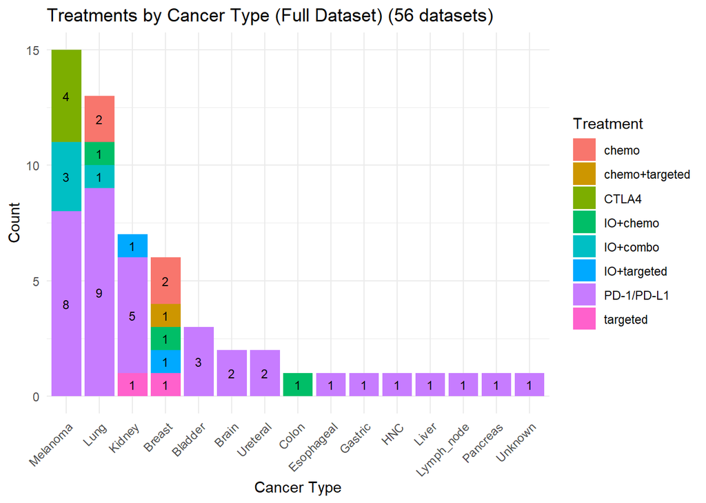

```r
# 1. Stacked Bar Plot: Treatments by Cancer Type
# Purpose: Visualize the distribution of treatments across cancer types
datasets <- gsub("^ICB_", "", unique(combined_clin$study))
common_datasets <- intersect(summary_table$Dataset, datasets)
summary_table_after <- summary_table[summary_table$Dataset %in% common_datasets, ]
# Find datasets in common between summary_table$Dataset and datasets
common_datasets <- intersect(summary_table$Dataset, datasets)

# Filter summary_table to keep only rows where Dataset is in common_datasets
summary_table_after <- summary_table[summary_table$Dataset %in% common_datasets, ]


# Function to generate a stacked bar plot
generate_treatment_plot <- function(data, title_prefix) {
  treatment_summary <- data %>%
    group_by(Cancer_Type, Treatments) %>%
    summarise(Count = n(), .groups = "drop") %>%
    mutate(Total_Count = sum(Count, na.rm = TRUE), .by = Cancer_Type) %>%
    arrange(desc(Total_Count)) %>%
    mutate(Cancer_Type = factor(Cancer_Type, levels = unique(Cancer_Type)))

  plot <- ggplot(treatment_summary, aes(x = Cancer_Type, y = Count, fill = Treatments)) +
    geom_bar(stat = "identity", position = "stack") +
    geom_text(aes(label = Count), position = position_stack(vjust = 0.5), size = 3) +
    theme_minimal() +
    labs(
      title = paste0(title_prefix, " (", length(unique(data$Dataset)), " datasets)"),
      x = "Cancer Type", y = "Count", fill = "Treatment"
    ) +
    theme(axis.text.x = element_text(angle = 45, hjust = 1))

  return(plot)
}

# Generate plots
treatment_bar_plot_full <- generate_treatment_plot(summary_table, "Treatments by Cancer Type (Full Dataset)")
treatment_bar_plot_filtered <- generate_treatment_plot(summary_table_after, "Treatments by Cancer Type (Filtered Dataset)")

# Display plots and captions
treatment_bar_plot_full
```

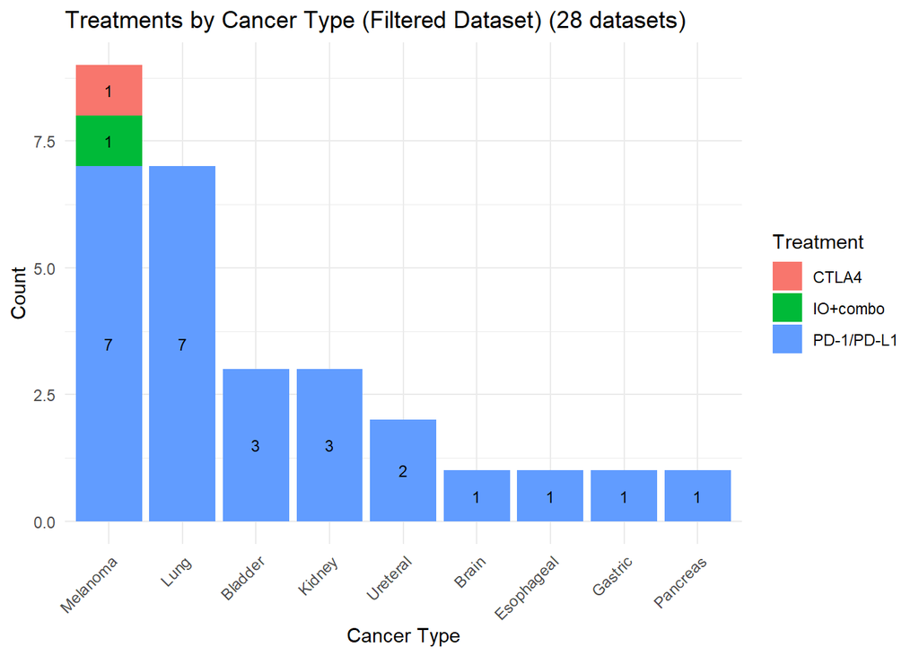

```r
treatment_bar_plot_filtered
```

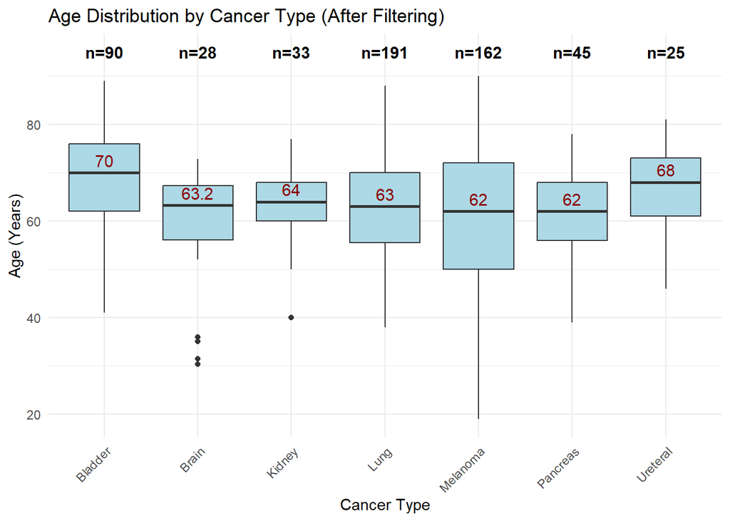

```r
# 2. Boxplot: Age Distribution by Cancer Type
# Purpose: Display the age distribution across cancer types with median and patient counts
create_age_distribution_plot <- function(data, title_suffix) {
  # Filter data for non-numeric ages
  filtered_data <- data %>%
    filter(!is.na(as.numeric(age)))

  # Calculate patient counts
  cancer_type_patient_counts <- filtered_data %>%
    group_by(cancer_type) %>%
    summarise(Patient_Count = n(), .groups = "drop")

  # Find max age
  max_age <- max(as.numeric(filtered_data$age), na.rm = TRUE)

  # Generate plot
  plot <- ggplot(filtered_data, aes(x = cancer_type, y = as.numeric(age))) +
    geom_boxplot(fill = "lightblue") +
    stat_summary(fun = median, geom = "text", aes(label = round(..y.., 1)), vjust = -0.5, color = "darkred", size = 4) +
    geom_text(data = cancer_type_patient_counts,
              aes(x = cancer_type, y = max_age + 5, label = paste0("n=", Patient_Count)),
              size = 4, fontface = "bold", color = "black") +
    theme_minimal() +
    labs(
      title = paste("Age Distribution by Cancer Type", title_suffix),
      x = "Cancer Type", y = "Age (Years)"
    ) +
    theme(axis.text.x = element_text(angle = 45, hjust = 1))

  return(plot)
}

# Generate plots
age_distribution_plot_before <- create_age_distribution_plot(combined_clin_before, "(Before Filtering)")
age_distribution_plot <- create_age_distribution_plot(combined_clin, "(After Filtering)")

# Save plots if needed
# ggsave(filename = file.path(Base_dir, "outputs/Dataprocessing_outputs/Plots/Age_Distribution_by_Cancer_Type_Before_Filtering.png"),
#        plot = age_distribution_plot_before, bg = "white")
# ggsave(filename = file.path(Base_dir, "outputs/Dataprocessing_outputs/Plots/Age_Distribution_by_Cancer_Type_After_Filtering.png"),
#        plot = age_distribution_plot, bg = "white")

age_distribution_plot
```

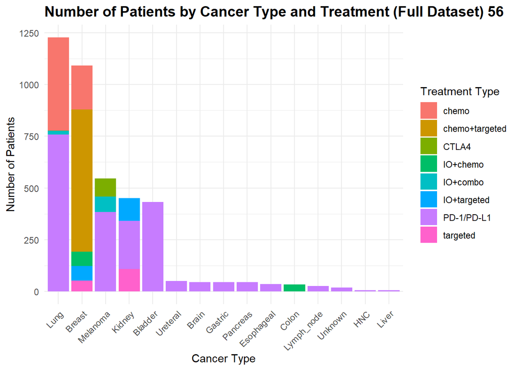

```r
# 3. Stacked Bar Plot: Patients by Cancer Type and Treatment
# Purpose: Summarize and visualize the number of patients across cancer types and treatments

# Function for summarizing data and generating bar plots
create_summary_plot <- function(data, title_prefix) {
  # Summarize data for the plot
  summary_plot_data <- data %>%
    group_by(Cancer_Type, Treatments) %>%
    summarise(Patients = sum(Patients, na.rm = TRUE), .groups = "drop") %>%
    mutate(Total_Patients = sum(Patients, na.rm = TRUE), .by = Cancer_Type)

  # Summarize data and calculate total patients per Cancer Type
  summary_plot_data <- summary_plot_data %>%
    group_by(Cancer_Type) %>%
    mutate(Total_Patients = sum(Patients, na.rm = TRUE)) %>%
    ungroup()

  # Reorder Cancer_Type by Total Patients
  summary_plot_data <- summary_plot_data %>%
    mutate(Cancer_Type = factor(Cancer_Type, levels = summary_plot_data %>%
                                  group_by(Cancer_Type) %>%
                                  summarise(Total_Patients = sum(Patients, na.rm = TRUE)) %>%
                                  arrange(desc(Total_Patients)) %>%
                                  pull(Cancer_Type)))

  # Create the bar plot ordered by Total Patients
  patient_bar_plot <- ggplot(summary_plot_data, aes(x = Cancer_Type, y = Patients, fill = Treatments)) +
    geom_bar(stat = "identity", position = "stack") +
    theme_minimal() +
    labs(
      title = paste0(title_prefix, " ", length(unique(data$Dataset)), " "),
      x = "Cancer Type", y = "Number of Patients", fill = "Treatment Type"
    ) +
    theme(
      axis.text.x = element_text(angle = 45, hjust = 1),
      plot.title = element_text(size = 14, face = "bold")
    )

  return(patient_bar_plot)
}

# Generate plots for both datasets
plot_full <- create_summary_plot(summary_table, "Number of Patients by Cancer Type and Treatment (Full Dataset)")
plot_filtered <- create_summary_plot(summary_table_after, "Number of Patients by Cancer Type and Treatment (Filtered Dataset)")

# Save the plots
# ggsave(filename = file.path(Base_dir, "outputs/Dataprocessing_outputs/Plots/Patients_by_Cancer_Type_and_Treatment_Full.png"), plot = plot_full, bg = "white")
# ggsave(filename = file.path(Base_dir, "outputs/Dataprocessing_outputs/Plots/Patients_by_Cancer_Type_and_Treatment_Filtered.png"), plot = plot_filtered, bg = "white")


# Display the plots
print(plot_full)
```

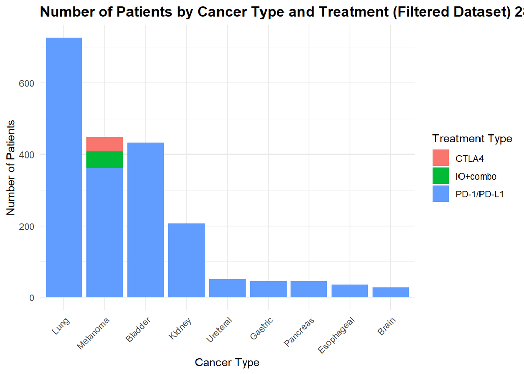

```r
print(plot_filtered)
```

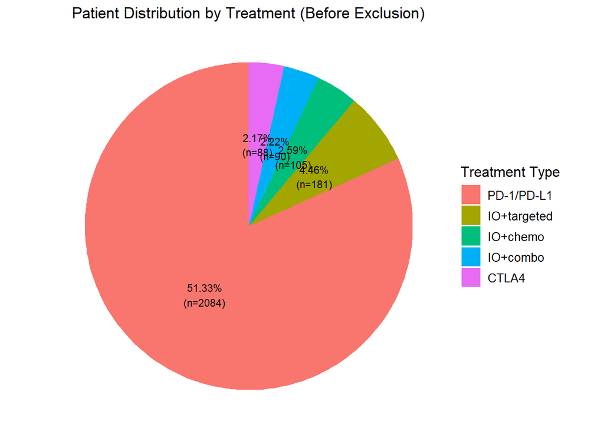

```r
# Function to create a pie chart
create_pie_chart <- function(data, title, fill_label, fill_column) {
  ggplot(data, aes(x = "", y = Total_Patients, fill = reorder(!!sym(fill_column), -Total_Patients))) +
    geom_bar(stat = "identity", width = 1) +
    coord_polar("y", start = 0) +
    theme_void() +
    geom_text(aes(label = paste0(Percentage, "%\n(n=", Total_Patients, ")")),
              position = position_stack(vjust = 0.5), size = 3) +
    labs(title = title, fill = fill_label) +
    theme(
      plot.title = element_text(hjust = 0.5, size = 13),
      legend.title = element_text(size = 12),
      legend.text = element_text(size = 10)
    )
}

# Summarize data for Treatment pie chart (Before Exclusion)
treatment_summary_before <- summary_table %>%
  group_by(Treatments) %>%
  summarise(Total_Patients = sum(Patients), .groups = "drop") %>%
  mutate(Percentage = round((Total_Patients / sum(Total_Patients)) * 100, 2)) %>%
  arrange(desc(Total_Patients))

# Exclude specific treatments
treatment_summary_filtered <- treatment_summary_before %>%
  filter(!Treatments %in% c("chemo", "chemo+targeted", "targeted"))

# Summarize data for Cancer Type pie chart (Before Exclusion)
cancer_type_summary_before <- summary_table %>%
  group_by(Cancer_Type) %>%
  summarise(Total_Patients = sum(Patients), .groups = "drop") %>%
  mutate(Percentage = round((Total_Patients / sum(Total_Patients)) * 100, 2)) %>%
  arrange(desc(Total_Patients))

# Combine smaller cancer types into "Others" for Before Exclusion
total_patients <- sum(cancer_type_summary_before$Total_Patients)
cancer_type_summary_combined <- cancer_type_summary_before %>%
  mutate(
    Cancer_Type = ifelse(
      Cancer_Type %in% c("Esophageal", "Colon", "Lymph_node", "Unknown", "HNC", "Liver"),
      "Others (Esophageal, Colon, Lymph_node, Unknown, HNC, Liver)",
      Cancer_Type
    )
  ) %>%
  group_by(Cancer_Type) %>%
  summarise(Total_Patients = sum(Total_Patients), .groups = "drop") %>%
  mutate(Percentage = round((Total_Patients / total_patients) * 100, 2)) %>%
  arrange(desc(Total_Patients))

# Create Treatment pie chart (Before Exclusion)
treatment_pie_before <- create_pie_chart(treatment_summary_filtered, "Patient Distribution by Treatment (Before Exclusion)", "Treatment Type", "Treatments")

# Create Cancer Type pie chart (Before Exclusion)
cancer_type_pie_before <- create_pie_chart(cancer_type_summary_combined, "Patient Distribution by Cancer Type (Before Exclusion)", "Cancer Type", "Cancer_Type")

# Filter summary_table to keep only rows with datasets in `common_datasets`
excluded_study <- sub("ICB_", "", unique(combined_clin$study))
summary_table_after <- summary_table[summary_table$Dataset %in% excluded_study, ]

# Summarize data for Treatment pie chart (After Exclusion)
treatment_summary_after <- summary_table_after %>%
  group_by(Treatments) %>%
  summarise(Total_Patients = sum(Patients), .groups = "drop") %>%
  mutate(Percentage = round((Total_Patients / sum(Total_Patients)) * 100, 2)) %>%
  arrange(desc(Total_Patients))

# Summarize data for Cancer Type pie chart (After Exclusion)
cancer_type_summary_after <- summary_table_after %>%
  group_by(Cancer_Type) %>%
  summarise(Total_Patients = sum(Patients), .groups = "drop") %>%
  mutate(Percentage = round((Total_Patients / sum(Total_Patients)) * 100, 2)) %>%
  arrange(desc(Total_Patients))

# Combine smaller cancer types into "Others" for After Exclusion
total_patients_after <- sum(cancer_type_summary_after$Total_Patients)
cancer_type_summary_combined_after <- cancer_type_summary_after %>%
  mutate(
    Cancer_Type = ifelse(
      Cancer_Type %in% c("Esophageal", "Pancreas", "Gastric", "Brain", "Ureteral"),
      "Others (Esophageal, Colon, Lymph_node, Unknown, HNC, Liver)",
      Cancer_Type
    )
  ) %>%
  group_by(Cancer_Type) %>%
  summarise(Total_Patients = sum(Total_Patients), .groups = "drop") %>%
  mutate(
    Percentage = round((Total_Patients / total_patients_after) * 100, 2)
  ) %>%
  arrange(desc(Total_Patients))

# Create Treatment pie chart (After Exclusion)
treatment_pie_after <- create_pie_chart(treatment_summary_after, "Patient Distribution by Treatment (After Exclusion)", "Treatment Type", "Treatments")

# Create Cancer Type pie chart (After Exclusion)
cancer_type_pie_after <- create_pie_chart(cancer_type_summary_combined_after, "Patient Distribution by Cancer Type (After Exclusion)", "Cancer Type", "Cancer_Type")

# Display pie charts
print(treatment_pie_before)
```

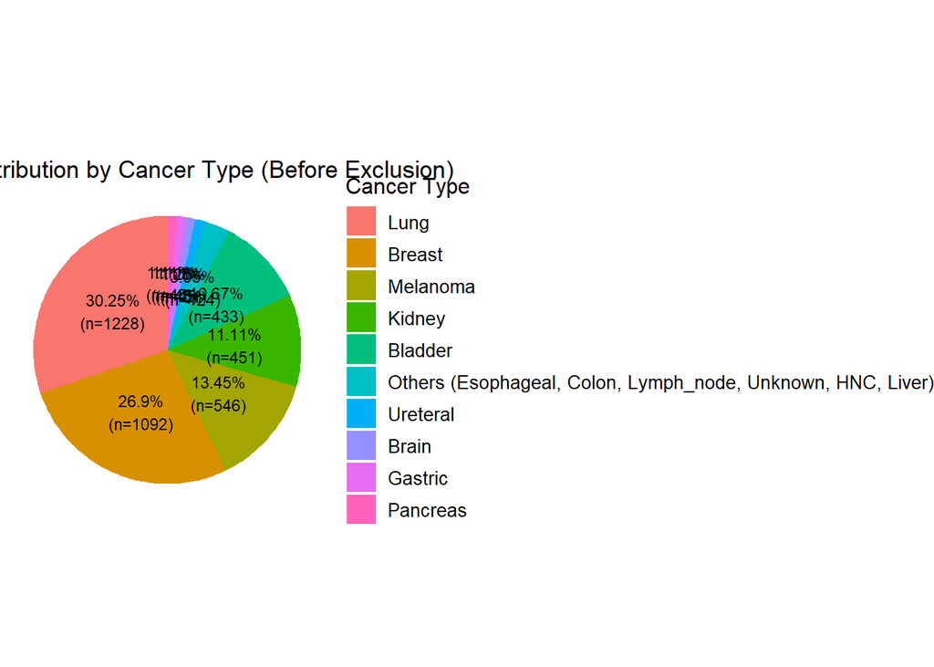

```r
print(cancer_type_pie_before)
```

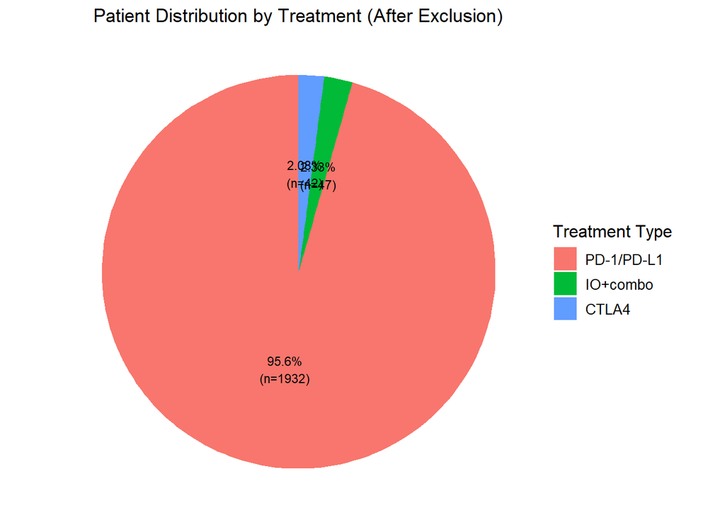

```r
print(treatment_pie_after)
```

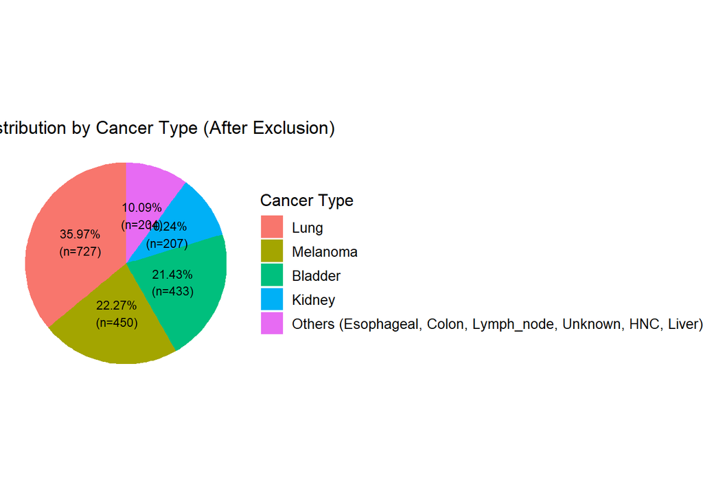

```r
print(cancer_type_pie_after)
```

```r
library(networkD3)
library(dplyr)

# Calculate total patients
total_patients <- sum(summary_table$Patients, na.rm = TRUE)

# Summarize data for Sankey diagram
summary_sankey <- summary_table %>%
  group_by(Cancer_Type, Treatments, Clinical_Endpoints) %>%
  summarise(Total_Patients = sum(Patients, na.rm = TRUE), .groups = "drop") %>%
  mutate(Response = ifelse(Cancer_Type %in% c("Bladder", "Lung", "Melanoma"), "Responders", "Non-Responders"))

# Prepare Nodes
nodes <- data.frame(
  name = c(
    paste0("Total Patients\n(n=", total_patients, ")"),
    paste0(unique(summary_sankey$Cancer_Type), "\n(n=",
           sapply(unique(summary_sankey$Cancer_Type), function(ct) sum(summary_sankey$Total_Patients[summary_sankey$Cancer_Type == ct])),
           ")"),
    paste0(unique(summary_sankey$Treatments), "\n(n=",
           sapply(unique(summary_sankey$Treatments), function(t) sum(summary_sankey$Total_Patients[summary_sankey$Treatments == t])),
           ")"),
    paste0(unique(summary_sankey$Clinical_Endpoints), "\n(n=",
           sapply(unique(summary_sankey$Clinical_Endpoints), function(ce) sum(summary_sankey$Total_Patients[summary_sankey$Clinical_Endpoints == ce])),
           ")"),
    "Responders", "Non-Responders"
  )
)

# Prepare Links
# First layer: Total Patients to Cancer Types
links <- summary_sankey %>%
  group_by(Cancer_Type) %>%
  summarise(Total_Patients = sum(Total_Patients)) %>%
  mutate(
    source = 0, # First node (Total Patients)
    target = match(paste0(Cancer_Type, "\n(n=",
                          sapply(Cancer_Type, function(ct) sum(summary_sankey$Total_Patients[summary_sankey$Cancer_Type == ct])),
                          ")"), nodes$name) - 1,
    value = Total_Patients
  ) %>%
  select(source, target, value)

# Second layer: Cancer Types to Treatments
links <- links %>%
  bind_rows(
    summary_sankey %>%
      mutate(
        source = match(paste0(Cancer_Type, "\n(n=",
                              sapply(Cancer_Type, function(ct) sum(summary_sankey$Total_Patients[summary_sankey$Cancer_Type == ct])),
                              ")"), nodes$name) - 1,
        target = match(paste0(Treatments, "\n(n=",
                              sapply(Treatments, function(t) sum(summary_sankey$Total_Patients[summary_sankey$Treatments == t])),
                              ")"), nodes$name) - 1,
        value = Total_Patients
      ) %>%
      select(source, target, value)
  )

# Third layer: Treatments to Responses
links <- links %>%
  bind_rows(
    summary_sankey %>%
      mutate(
        source = match(paste0(Treatments, "\n(n=",
                              sapply(Treatments, function(t) sum(summary_sankey$Total_Patients[summary_sankey$Treatments == t])),
                              ")"), nodes$name) - 1,
        target = ifelse(Response == "Responders", match("Responders", nodes$name) - 1, match("Non-Responders", nodes$name) - 1),
        value = Total_Patients
      ) %>%
      select(source, target, value)
  )

# Fourth layer: Treatments to Clinical Endpoints
links <- links %>%
  bind_rows(
    summary_sankey %>%
      mutate(
        source = match(paste0(Treatments, "\n(n=",
                              sapply(Treatments, function(t) sum(summary_sankey$Total_Patients[summary_sankey$Treatments == t])),
                              ")"), nodes$name) - 1,
        target = match(paste0(Clinical_Endpoints, "\n(n=",
                              sapply(Clinical_Endpoints, function(ce) sum(summary_sankey$Total_Patients[summary_sankey$Clinical_Endpoints == ce])),
                              ")"), nodes$name) - 1,
        value = Total_Patients
      ) %>%
      select(source, target, value)
  )

# Create Sankey Diagram
sankey <- sankeyNetwork(
  Links = links, Nodes = nodes,
  Source = "source", Target = "target",
  Value = "value", NodeID = "name",
  units = "Patients", fontSize = 12, nodeWidth = 30,
  width = 800, height = 450,
  nodePadding = 10
)

# Save Sankey Diagram as HTML
# saveNetwork(sankey, file = file.path("~/BHK lab/EcoTyper_Project//outputs/", "Sankey_Cancer_Treatments_Response_Annotated.html"))


# Display the Sankey Diagram
sankey
```

[interactive chart not shown]

```r
generate_annotated_sankey <- function(data, output_filename, output_dir = "~/BHK lab/Ecotyper/outputs/") {
  # Ensure the output directory exists
  if (!dir.exists(output_dir)) {
    dir.create(output_dir, recursive = TRUE)
  }

  # Calculate the total number of patients for percentages
  total_patients <- sum(data$Patients, na.rm = TRUE)

  # Summarize data for Sankey diagram
  summary_sankey <- data %>%
    group_by(Cancer_Type, Treatments) %>%
    summarise(Total_Patients = sum(Patients, na.rm = TRUE), .groups = "drop") %>%
    mutate(Response = ifelse(Cancer_Type %in% c("Bladder", "Lung", "Melanoma"), "Responders", "Non-Responders"))

  # Prepare Nodes with percentages and counts
  nodes <- data.frame(
    name = c(
      paste0("Total Patients (n=", total_patients, ")"),
      paste0(unique(summary_sankey$Cancer_Type), " (n=",
             sapply(unique(summary_sankey$Cancer_Type), function(x)
               sum(summary_sankey$Total_Patients[summary_sankey$Cancer_Type == x])),
             ", ",
             round(sapply(unique(summary_sankey$Cancer_Type), function(x)
               sum(summary_sankey$Total_Patients[summary_sankey$Cancer_Type == x]) / total_patients * 100), 2),
             "%)"),
      paste0(unique(summary_sankey$Treatments), " (n=",
             sapply(unique(summary_sankey$Treatments), function(x)
               sum(summary_sankey$Total_Patients[summary_sankey$Treatments == x])),
             ", ",
             round(sapply(unique(summary_sankey$Treatments), function(x)
               sum(summary_sankey$Total_Patients[summary_sankey$Treatments == x]) / total_patients * 100), 2),
             "%)"),
      paste0(c("Responders", "Non-Responders"), " (n=",
             c(sum(summary_sankey$Total_Patients[summary_sankey$Response == "Responders"]),
               sum(summary_sankey$Total_Patients[summary_sankey$Response == "Non-Responders"])),
             ", ",
             c(round(sum(summary_sankey$Total_Patients[summary_sankey$Response == "Responders"]) / total_patients * 100, 2),
               round(sum(summary_sankey$Total_Patients[summary_sankey$Response == "Non-Responders"]) / total_patients * 100, 2)),
             "%)")
    )
  )

  # Prepare Links
  links <- summary_sankey %>%
    mutate(
      source_total = 0, # Link all cancer types to Total Patients node
      source_cancer = match(Cancer_Type, gsub(" \\(.*", "", nodes$name)) - 1,
      target_treatment = match(Treatments, gsub(" \\(.*", "", nodes$name)) - 1,
      target_response = ifelse(Response == "Responders", match("Responders", gsub(" \\(.*", "", nodes$name)) - 1, match("Non-Responders", gsub(" \\(.*", "", nodes$name)) - 1)
    ) %>%
    select(source = source_total, target = source_cancer, value = Total_Patients) %>%
    bind_rows(
      summary_sankey %>%
        mutate(
          source = match(Cancer_Type, gsub(" \\(.*", "", nodes$name)) - 1,
          target = match(Treatments, gsub(" \\(.*", "", nodes$name)) - 1,
          value = Total_Patients
        ) %>%
        select(source, target, value)
    ) %>%
    bind_rows(
      summary_sankey %>%
        mutate(
          source = match(Treatments, gsub(" \\(.*", "", nodes$name)) - 1,
          target = ifelse(Response == "Responders", match("Responders", gsub(" \\(.*", "", nodes$name)) - 1, match("Non-Responders", gsub(" \\(.*", "", nodes$name)) - 1),
          value = Total_Patients
        ) %>%
        select(source, target, value)
    )

  # Create Sankey Diagram
  sankey <- sankeyNetwork(
    Links = links, Nodes = nodes,
    Source = "source", Target = "target",
    Value = "value", NodeID = "name",
    width = 1020, height = 480,
    units = "Patients", fontSize = 13, nodeWidth = 30
  )

  # Save Sankey Diagram as HTML
  saveNetwork(sankey, file = file.path(output_dir, output_filename))

  # Return the Sankey Diagram for visualization in the session
  return(sankey)
}

# Usage
# For summary_table
sankey_beforee <- generate_annotated_sankey(summary_table, "Sankey_Before_Exclusion.html")

# For summary_table_after
sankey_afterr <- generate_annotated_sankey(summary_table_after, "Sankey_After_Exclusion.html")

sankey_beforee
```

[interactive chart not shown]

```r
sankey_afterr
```

[interactive chart not shown]

```r
# saveNetwork(sankey_beforee, file = "~/BHK lab/EcoTyper_Project/outputs/Dataprocessing_outputs/Plots/2Sankey_Cancer_Treatments_Endpoints_Before.html")
# saveNetwork(sankey_afterr, file = "~/BHK lab/EcoTyper_Project/outputs/Dataprocessing_outputs/Plots/2Sankey_Cancer_Treatments_Endpoints_After2.html")
```

```r
# Function to generate a Sankey diagram with percentages
generate_sankey_with_percentages <- function(data, output_filename) {
  # Calculate total patients
  total_patients <- sum(data$Patients, na.rm = TRUE)

  # Summarize data for Sankey diagram
  summary_sankey <- data %>%
    group_by(Cancer_Type, Treatments, Clinical_Endpoints) %>%
    summarise(Total_Patients = sum(Patients, na.rm = TRUE), .groups = "drop")

  # Prepare Nodes with counts and percentages
  nodes <- data.frame(
    name = c(
      paste0("Total Patients\n(n=", total_patients, ", 100%)"),
      paste0(unique(summary_sankey$Cancer_Type), "\n(n=",
             sapply(unique(summary_sankey$Cancer_Type), function(ct) sum(summary_sankey$Total_Patients[summary_sankey$Cancer_Type == ct])),
             ", ",
             round(sapply(unique(summary_sankey$Cancer_Type), function(ct)
               sum(summary_sankey$Total_Patients[summary_sankey$Cancer_Type == ct]) / total_patients * 100), 2),
             "%)"),
      paste0(unique(summary_sankey$Treatments), "\n(n=",
             sapply(unique(summary_sankey$Treatments), function(t) sum(summary_sankey$Total_Patients[summary_sankey$Treatments == t])),
             ", ",
             round(sapply(unique(summary_sankey$Treatments), function(t)
               sum(summary_sankey$Total_Patients[summary_sankey$Treatments == t]) / total_patients * 100), 2),
             "%)"),
      paste0(unique(summary_sankey$Clinical_Endpoints), "\n(n=",
             sapply(unique(summary_sankey$Clinical_Endpoints), function(ce) sum(summary_sankey$Total_Patients[summary_sankey$Clinical_Endpoints == ce])),
             ", ",
             round(sapply(unique(summary_sankey$Clinical_Endpoints), function(ce)
               sum(summary_sankey$Total_Patients[summary_sankey$Clinical_Endpoints == ce]) / total_patients * 100), 2),
             "%)")
    )
  )

  # Prepare Links
  # First layer: Total Patients to Cancer Types
  links <- summary_sankey %>%
    group_by(Cancer_Type) %>%
    summarise(Total_Patients = sum(Total_Patients)) %>%
    mutate(
      source = 0, # First node (Total Patients)
      target = match(paste0(Cancer_Type, "\n(n=",
                            sapply(Cancer_Type, function(ct) sum(summary_sankey$Total_Patients[summary_sankey$Cancer_Type == ct])),
                            ", ",
                            round(sapply(Cancer_Type, function(ct)
                              sum(summary_sankey$Total_Patients[summary_sankey$Cancer_Type == ct]) / total_patients * 100), 2),
                            "%)"), nodes$name) - 1,
      value = Total_Patients
    ) %>%
    select(source, target, value)

  # Second layer: Cancer Types to Treatments
  links <- links %>%
    bind_rows(
      summary_sankey %>%
        mutate(
          source = match(paste0(Cancer_Type, "\n(n=",
                                sapply(Cancer_Type, function(ct) sum(summary_sankey$Total_Patients[summary_sankey$Cancer_Type == ct])),
                                ", ",
                                round(sapply(Cancer_Type, function(ct)
                                  sum(summary_sankey$Total_Patients[summary_sankey$Cancer_Type == ct]) / total_patients * 100), 2),
                                "%)"), nodes$name) - 1,
          target = match(paste0(Treatments, "\n(n=",
                                sapply(Treatments, function(t) sum(summary_sankey$Total_Patients[summary_sankey$Treatments == t])),
                                ", ",
                                round(sapply(Treatments, function(t)
                                  sum(summary_sankey$Total_Patients[summary_sankey$Treatments == t]) / total_patients * 100), 2),
                                "%)"), nodes$name) - 1,
          value = Total_Patients
        ) %>%
        select(source, target, value)
    )

  # Third layer: Treatments to Clinical Endpoints
  links <- links %>%
    bind_rows(
      summary_sankey %>%
        mutate(
          source = match(paste0(Treatments, "\n(n=",
                                sapply(Treatments, function(t) sum(summary_sankey$Total_Patients[summary_sankey$Treatments == t])),
                                ", ",
                                round(sapply(Treatments, function(t)
                                  sum(summary_sankey$Total_Patients[summary_sankey$Treatments == t]) / total_patients * 100), 2),
                                "%)"), nodes$name) - 1,
          target = match(paste0(Clinical_Endpoints, "\n(n=",
                                sapply(Clinical_Endpoints, function(ce) sum(summary_sankey$Total_Patients[summary_sankey$Clinical_Endpoints == ce])),
                                ", ",
                                round(sapply(Clinical_Endpoints, function(ce)
                                  sum(summary_sankey$Total_Patients[summary_sankey$Clinical_Endpoints == ce]) / total_patients * 100), 2),
                                "%)"), nodes$name) - 1,
          value = Total_Patients
        ) %>%
        select(source, target, value)
    )

  # Create Sankey Diagram
  sankey <- sankeyNetwork(
    Links = links, Nodes = nodes,
    Source = "source", Target = "target",
    Value = "value", NodeID = "name",
    units = "Patients", fontSize = 12, nodeWidth = 30,
    width = 1050, height = 600,
    nodePadding = 10
  )

  # Return the Sankey Diagram for visualization in the session
  return(sankey)
}

# Usage Example
sankey_before <- generate_sankey_with_percentages(summary_table)
sankey_after <- generate_sankey_with_percentages(summary_table_after)

sankey_before
```

[interactive chart not shown]

```r
sankey_after
```

[interactive chart not shown]

```r
# saveNetwork(sankey_befor, file = "~/BHK lab/EcoTyper_Project/outputs/Dataprocessing_outputs/Plots/Sankey_Cancer_Treatments_Endpoints_Before.html")
# saveNetwork(sankey_after, file = "~/BHK lab/EcoTyper_Project/outputs/Dataprocessing_outputs/Plots/Sankey_Cancer_Treatments_Endpoints_After.html")
```

## Detailed clinical characteristics of the IO datasets

processes clinical data from multiple datasets, extracts key characteristics, and formats them into a summary table.

```r
# Initialize the results list
results <- list()

# Loop through unique studies in combined_clin
for (study_name in unique(combined_clin$study)) {

  # Subset the data for the current study
  study_data <- combined_clin[combined_clin$study == study_name, ]

  # Number of samples
  n_samples <- nrow(study_data)

  # Expression type: Adjust based on actual data
  expression_type <- ifelse(any(study_data$rna == "rnaseq"), "TPM", ifelse(any(study_data$rna == "microarray"), "log2gNor", NA))

  # Age calculations
  study_data$age <- as.numeric(as.character(study_data$age))
  valid_ages <- na.omit(study_data$age)
  age_median <- if(length(valid_ages) > 0) round(median(valid_ages, na.rm = TRUE), 1) else NA
  age_iqr <- if(length(valid_ages) > 1) round(IQR(valid_ages, na.rm = TRUE), 1) else NA
  age_na <- sum(is.na(study_data$age))

  # Sex calculations
  n_female <- sum(study_data$sex == "F", na.rm = TRUE)
  n_male <- sum(study_data$sex == "M", na.rm = TRUE)
  sex_na <- sum(is.na(study_data$sex))

  # Cancer type (assuming the cancer type is consistent within the study)
  cancer_type <- unique(study_data$cancer_type)

  # Treatment type
  treatment_type <- paste(unique(study_data$treatment), collapse = ", ")

  # Response counts
  no_response <- sum(study_data$response == "NR", na.rm = TRUE)
  response <- sum(study_data$response == "R", na.rm = TRUE)

  # PFS counts
  no_progression <- sum(study_data$event_occurred_pfs == 0, na.rm = TRUE)
  progression <- sum(study_data$event_occurred_pfs == 1, na.rm = TRUE)
  pfs_median <- if (!all(is.na(study_data$survival_time_pfs))) round(median(na.omit(study_data$survival_time_pfs), na.rm = TRUE), 1) else NA
  pfs_iqr <- if (!all(is.na(study_data$survival_time_pfs))) round(IQR(na.omit(study_data$survival_time_pfs), na.rm = TRUE), 1) else NA

  # OS counts
  alive <- sum(study_data$event_occurred_os == 0, na.rm = TRUE)
  dead <- sum(study_data$event_occurred_os == 1, na.rm = TRUE)
  os_median <- if (!all(is.na(study_data$survival_time_os))) round(median(na.omit(study_data$survival_time_os), na.rm = TRUE), 1) else NA
  os_iqr <- if (!all(is.na(study_data$survival_time_os))) round(IQR(na.omit(study_data$survival_time_os), na.rm = TRUE), 1) else NA

  # Compile the results for this study
  results[[study_name]] <- data.frame(
    Study = study_name,
    N = n_samples,
    Expression = expression_type,
    Age_Median = age_median,
    Age_IQR = age_iqr,
    Age_NA = age_na,
    Female = n_female,
    Male = n_male,
    Sex_NA = sex_na,
    Cancer_Type = cancer_type,
    Treatment_Type = treatment_type,
    No_Response = no_response,
    Response = response,
    No_Progression = no_progression,
    Progressed = progression,
    PFS_Median = pfs_median,
    PFS_IQR = pfs_iqr,
    Alive = alive,
    Dead = dead,
    OS_Median = os_median,
    OS_IQR = os_iqr,
    stringsAsFactors = FALSE
  )
}

# Combine all results into a single dataframe
results_df <- do.call(rbind, results)

kable(results_df, caption = "Detailed clinical characteristics of the IO datasets") %>%
  kable_styling(bootstrap_options = c("striped", "hover", "condensed"), full_width = F) %>%
  scroll_box(height = "400px")
```

Detailed clinical characteristics of the IO datasets

|  | Study | N | Expression | Age_Median | Age_IQR | Age_NA | Female | Male | Sex_NA | Cancer_Type | Treatment_Type | No_Response | Response | No_Progression | Progressed | PFS_Median | PFS_IQR | Alive | Dead | OS_Median | OS_IQR |
| --- | --- | --- | --- | --- | --- | --- | --- | --- | --- | --- | --- | --- | --- | --- | --- | --- | --- | --- | --- | --- | --- |
| ICB_Auslander__Melanoma__PD-(L)1 | ICB_Auslander__Melanoma__PD-(L)1 | 27 | TPM | 72.0 | 28.5 | 0 | 0 | 0 | 27 | Melanoma | PD-1/PD-L1 | 26 | 1 | 0 | 0 | NA | NA | 0 | 0 | NA | NA |
| ICB_Cloughesy__Brain__PD-(L)1 | ICB_Cloughesy__Brain__PD-(L)1 | 28 | TPM | 63.2 | 11.2 | 0 | 17 | 11 | 0 | Brain | PD-1/PD-L1 | 21 | 1 | 1 | 27 | 2.6 | 3.4 | 8 | 20 | 9.1 | 7.4 |
| ICB_Damrauer__Bladder__PD-(L)1 | ICB_Damrauer__Bladder__PD-(L)1 | 90 | TPM | 70.0 | 14.0 | 0 | 34 | 56 | 0 | Bladder | PD-1/PD-L1 | 69 | 17 | 10 | 79 | 2.1 | 3.6 | 33 | 57 | 5.9 | 7.9 |
| ICB_Fehrenbacher__Lung__PD-(L)1 | ICB_Fehrenbacher__Lung__PD-(L)1 | 95 | TPM | NA | NA | 95 | 27 | 68 | 0 | Lung | PD-1/PD-L1 | 56 | 14 | 5 | 90 | 2.8 | 7.1 | 16 | 79 | 11.1 | 20.1 |
| ICB_Gide__Melanoma__PD-(L)1 | ICB_Gide__Melanoma__PD-(L)1 | 41 | NA | 66.0 | 21.0 | 0 | 15 | 26 | 0 | Melanoma | PD-1/PD-L1 | 19 | 19 | 12 | 29 | 9.0 | 27.0 | 17 | 24 | 20.2 | 30.5 |
| ICB_Hugo__Melanoma__PD-(L)1 | ICB_Hugo__Melanoma__PD-(L)1 | 27 | NA | 61.0 | 14.5 | 0 | 8 | 19 | 0 | Melanoma | PD-1/PD-L1 | 13 | 14 | 0 | 0 | NA | NA | 15 | 12 | 14.4 | 18.2 |
| ICB_IMmotion150__Kidney__PD-(L)1 | ICB_IMmotion150__Kidney__PD-(L)1 | 107 | TPM | NA | NA | 107 | 0 | 0 | 107 | Kidney | PD-1/PD-L1 | 32 | 22 | 0 | 0 | NA | NA | 0 | 0 | NA | NA |
| ICB_Jerby_Arnon__Melanoma__PD-(L)1 | ICB_Jerby_Arnon__Melanoma__PD-(L)1 | 112 | NA | NA | NA | 112 | 49 | 56 | 7 | Melanoma | PD-1/PD-L1 | 53 | 43 | 33 | 72 | 3.9 | 10.4 | 0 | 0 | NA | NA |
| ICB_Jung__Lung__PD-(L)1 | ICB_Jung__Lung__PD-(L)1 | 27 | NA | 62.0 | 10.0 | 0 | 5 | 22 | 0 | Lung | PD-1/PD-L1 | 19 | 8 | 6 | 21 | 2.0 | 5.1 | 0 | 0 | NA | NA |
| ICB_Kim__Gastric__PD-(L)1 | ICB_Kim__Gastric__PD-(L)1 | 45 | NA | NA | NA | 45 | 0 | 0 | 45 | Gastric | PD-1/PD-L1 | 18 | 13 | 0 | 0 | NA | NA | 0 | 0 | NA | NA |
| ICB_Limagne1__Lung__PD-(L)1 | ICB_Limagne1__Lung__PD-(L)1 | 70 | NA | NA | NA | 70 | 0 | 0 | 70 | Lung | PD-1/PD-L1 | 52 | 17 | 18 | 52 | 2.7 | 3.8 | 0 | 0 | NA | NA |
| ICB_Limagne2__Lung__PD-(L)1 | ICB_Limagne2__Lung__PD-(L)1 | 26 | NA | NA | NA | 26 | 0 | 0 | 26 | Lung | PD-1/PD-L1 | 16 | 6 | 6 | 20 | 3.1 | 10.4 | 0 | 0 | NA | NA |
| ICB_Liu__Melanoma__IO+combo | ICB_Liu__Melanoma__IO+combo | 47 | NA | NA | NA | 47 | 20 | 27 | 0 | Melanoma | IO+combo | 26 | 17 | 10 | 37 | 3.4 | 24.2 | 16 | 31 | 14.0 | 25.0 |
| ICB_Liu__Melanoma__PD-(L)1 | ICB_Liu__Melanoma__PD-(L)1 | 74 | NA | NA | NA | 74 | 30 | 44 | 0 | Melanoma | PD-1/PD-L1 | 34 | 35 | 25 | 49 | 6.4 | 17.9 | 43 | 31 | 19.0 | 17.6 |
| ICB_Mariathasan__Bladder__PD-(L)1 | ICB_Mariathasan__Bladder__PD-(L)1 | 195 | NA | NA | NA | 195 | 42 | 153 | 0 | Bladder | PD-1/PD-L1 | 91 | 42 | 0 | 0 | NA | NA | 67 | 128 | 8.9 | 15.9 |
| ICB_Mariathasan__Kidney__PD-(L)1 | ICB_Mariathasan__Kidney__PD-(L)1 | 67 | NA | NA | NA | 67 | 10 | 57 | 0 | Kidney | PD-1/PD-L1 | 37 | 9 | 0 | 0 | NA | NA | 20 | 47 | 7.0 | 11.3 |
| ICB_Mariathasan__Ureteral__PD-(L)1 | ICB_Mariathasan__Ureteral__PD-(L)1 | 26 | NA | NA | NA | 26 | 10 | 16 | 0 | Ureteral | PD-1/PD-L1 | 13 | 5 | 0 | 0 | NA | NA | 8 | 18 | 10.3 | 15.4 |
| ICB_Miao1__Kidney__PD-(L)1 | ICB_Miao1__Kidney__PD-(L)1 | 33 | NA | 64.0 | 8.0 | 0 | 9 | 24 | 0 | Kidney | PD-1/PD-L1 | 18 | 10 | 25 | 8 | 2.9 | 11.7 | 10 | 23 | 12.4 | 14.2 |
| ICB_Padron__Pancreas__PD-(L)1 | ICB_Padron__Pancreas__PD-(L)1 | 45 | NA | 62.0 | 12.0 | 0 | 19 | 26 | 0 | Pancreas | PD-1/PD-L1 | 20 | 3 | 6 | 39 | 5.8 | 6.2 | 11 | 34 | 9.7 | 11.3 |
| ICB_Powles__Bladder__PD-(L)1 | ICB_Powles__Bladder__PD-(L)1 | 148 | TPM | NA | NA | 148 | 0 | 0 | 148 | Bladder | PD-1/PD-L1 | 46 | 27 | 0 | 0 | NA | NA | 0 | 0 | NA | NA |
| ICB_Prat__Lung__PD-(L)1 | ICB_Prat__Lung__PD-(L)1 | 35 | log2gNor | 59.0 | 19.0 | 0 | 8 | 27 | 0 | Lung | PD-1/PD-L1 | 18 | 10 | 10 | 25 | 3.2 | 4.7 | 0 | 0 | NA | NA |
| ICB_Prat__Melanoma__PD-(L)1 | ICB_Prat__Melanoma__PD-(L)1 | 25 | log2gNor | 59.0 | 21.0 | 0 | 7 | 18 | 0 | Melanoma | PD-1/PD-L1 | 15 | 10 | 7 | 18 | 3.2 | 4.8 | 0 | 0 | NA | NA |
| ICB_Puch__Melanoma__PD-(L)1 | ICB_Puch__Melanoma__PD-(L)1 | 55 | NA | NA | NA | 55 | 0 | 0 | 55 | Melanoma | PD-1/PD-L1 | 35 | 14 | 0 | 0 | NA | NA | 0 | 0 | NA | NA |
| ICB_Ravi__Lung__PD-(L)1 | ICB_Ravi__Lung__PD-(L)1 | 130 | TPM | 64.0 | 15.0 | 1 | 70 | 60 | 0 | Lung | PD-1/PD-L1 | 62 | 45 | 27 | 91 | 4.1 | 7.9 | 62 | 63 | 10.7 | 14.6 |
| ICB_Rittmeyer__Lung__PD-(L)1 | ICB_Rittmeyer__Lung__PD-(L)1 | 344 | TPM | NA | NA | 344 | 125 | 219 | 0 | Lung | PD-1/PD-L1 | 221 | 53 | 30 | 314 | 2.5 | 5.5 | 107 | 237 | 10.8 | 16.9 |
| ICB_Snyder__Ureteral__PD-(L)1 | ICB_Snyder__Ureteral__PD-(L)1 | 25 | NA | 68.0 | 12.0 | 0 | 3 | 22 | 0 | Ureteral | PD-1/PD-L1 | 10 | 8 | 6 | 19 | 2.5 | 11.1 | 8 | 17 | 11.6 | 15.3 |
| ICB_Van_Allen__Melanoma__CTLA4 | ICB_Van_Allen__Melanoma__CTLA4 | 42 | NA | 61.0 | 24.0 | 0 | 14 | 28 | 0 | Melanoma | CTLA4 | 30 | 9 | 6 | 36 | 2.8 | 7.0 | 13 | 29 | 12.8 | 27.8 |
| ICB_VanDenEnde__Esophageal__PD-(L)1 | ICB_VanDenEnde__Esophageal__PD-(L)1 | 35 | NA | NA | NA | 35 | 0 | 0 | 35 | Esophageal | PD-1/PD-L1 | 20 | 12 | 0 | 0 | NA | NA | 0 | 0 | NA | NA |

```r
#write.csv(results_df, file = file.path(Base_dir, "outputs/Dataprocessing_outputs", "Detailed_clinical_characteristics_of_the_IO_datasets.csv"), row.names = FALSE)
```

## Table S4: Detailed clinical characteristics of the IO dataset stratify by sex

Processes clinical data stratified by sex from multiple datasets, extracts key characteristics, and formats them into a summary table.

```r
# Initialize the results list for combined_clin_sex
results_sex <- list()

# Loop through unique studies in combined_clin_sex
for (study_name in unique(combined_clin_sex$study)) {

  # Subset the data for the current study
  study_data <- combined_clin_sex[combined_clin_sex$study == study_name, ]

  # Number of samples
  n_samples <- nrow(study_data)

  # Expression type: Adjust based on actual data
  expression_type <- ifelse(any(study_data$rna == "rnaseq"), "TPM", ifelse(any(study_data$rna == "microarray"), "log2gNor", NA))

  # Age calculations
  study_data$age <- as.numeric(as.character(study_data$age))
  valid_ages <- na.omit(study_data$age)
  age_median <- if(length(valid_ages) > 0) round(median(valid_ages, na.rm = TRUE), 1) else NA
  age_iqr <- if(length(valid_ages) > 1) round(IQR(valid_ages, na.rm = TRUE), 1) else NA
  age_na <- sum(is.na(study_data$age))

  # Sex calculations
  n_female <- sum(study_data$sex == "F", na.rm = TRUE)
  n_male <- sum(study_data$sex == "M", na.rm = TRUE)
  sex_na <- sum(is.na(study_data$sex))

  # Cancer type (assuming the cancer type is consistent within the study)
  cancer_type <- unique(study_data$cancer_type)

  # Treatment type
  treatment_type <- paste(unique(study_data$treatment), collapse = ", ")

  # Response counts
  no_response <- sum(study_data$response == "NR", na.rm = TRUE)
  response <- sum(study_data$response == "R", na.rm = TRUE)

  # PFS counts
  no_progression <- sum(study_data$event_occurred_pfs == 0, na.rm = TRUE)
  progression <- sum(study_data$event_occurred_pfs == 1, na.rm = TRUE)
  pfs_median <- if (!all(is.na(study_data$survival_time_pfs))) round(median(na.omit(study_data$survival_time_pfs), na.rm = TRUE), 1) else NA
  pfs_iqr <- if (!all(is.na(study_data$survival_time_pfs))) round(IQR(na.omit(study_data$survival_time_pfs), na.rm = TRUE), 1) else NA

  # OS counts
  alive <- sum(study_data$event_occurred_os == 0, na.rm = TRUE)
  dead <- sum(study_data$event_occurred_os == 1, na.rm = TRUE)
  os_median <- if (!all(is.na(study_data$survival_time_os))) round(median(na.omit(study_data$survival_time_os), na.rm = TRUE), 1) else NA
  os_iqr <- if (!all(is.na(study_data$survival_time_os))) round(IQR(na.omit(study_data$survival_time_os), na.rm = TRUE), 1) else NA

  # Compile the results for this study
  results_sex[[study_name]] <- data.frame(
    Study = study_name,
    N = n_samples,
    Expression = expression_type,
    Age_Median = age_median,
    Age_IQR = age_iqr,
    Age_NA = age_na,
    Female = n_female,
    Male = n_male,
    Sex_NA = sex_na,
    Cancer_Type = cancer_type,
    Treatment_Type = treatment_type,
    No_Response = no_response,
    Response = response,
    No_Progression = no_progression,
    Progressed = progression,
    PFS_Median = pfs_median,
    PFS_IQR = pfs_iqr,
    Alive = alive,
    Dead = dead,
    OS_Median = os_median,
    OS_IQR = os_iqr,
    stringsAsFactors = FALSE
  )}

# Combine all results into a single dataframe
results_df_sex <- do.call(rbind, results_sex)

# Display
kable(results_df_sex, caption = "Detailed clinical characteristics of the IO datasets") %>%
  kable_styling(bootstrap_options = c("striped", "hover", "condensed"), full_width = F) %>%
  scroll_box(height = "400px")
```

Detailed clinical characteristics of the IO datasets

|  | Study | N | Expression | Age_Median | Age_IQR | Age_NA | Female | Male | Sex_NA | Cancer_Type | Treatment_Type | No_Response | Response | No_Progression | Progressed | PFS_Median | PFS_IQR | Alive | Dead | OS_Median | OS_IQR |
| --- | --- | --- | --- | --- | --- | --- | --- | --- | --- | --- | --- | --- | --- | --- | --- | --- | --- | --- | --- | --- | --- |
| ICB_Ascierto__Kidney__PD-(L)1__F | ICB_Ascierto__Kidney__PD-(L)1__F | 4 | log2gNor | NA | NA | 4 | 4 | 0 | 0 | Kidney | PD-1/PD-L1 | 3 | 1 | 0 | 0 | NA | NA | 0 | 0 | NA | NA |
| ICB_Ascierto__Kidney__PD-(L)1__M | ICB_Ascierto__Kidney__PD-(L)1__M | 7 | log2gNor | NA | NA | 7 | 0 | 7 | 0 | Kidney | PD-1/PD-L1 | 4 | 3 | 0 | 0 | NA | NA | 0 | 0 | NA | NA |
| ICB_Cloughesy__Brain__PD-(L)1__F | ICB_Cloughesy__Brain__PD-(L)1__F | 17 | TPM | 63.3 | 10.4 | 0 | 17 | 0 | 0 | Brain | PD-1/PD-L1 | 14 | 0 | 0 | 17 | 2.4 | 0.4 | 4 | 13 | 8.8 | 7.0 |
| ICB_Cloughesy__Brain__PD-(L)1__M | ICB_Cloughesy__Brain__PD-(L)1__M | 11 | TPM | 63.2 | 11.3 | 0 | 0 | 11 | 0 | Brain | PD-1/PD-L1 | 7 | 1 | 1 | 10 | 3.6 | 7.6 | 4 | 7 | 13.0 | 7.6 |
| ICB_Damrauer__Bladder__PD-(L)1__F | ICB_Damrauer__Bladder__PD-(L)1__F | 34 | TPM | 70.5 | 11.0 | 0 | 34 | 0 | 0 | Bladder | PD-1/PD-L1 | 24 | 8 | 6 | 27 | 2.1 | 3.8 | 14 | 20 | 6.3 | 6.3 |
| ICB_Damrauer__Bladder__PD-(L)1__M | ICB_Damrauer__Bladder__PD-(L)1__M | 56 | TPM | 70.0 | 13.2 | 0 | 0 | 56 | 0 | Bladder | PD-1/PD-L1 | 45 | 9 | 4 | 52 | 2.1 | 3.0 | 19 | 37 | 5.2 | 10.6 |
| ICB_Fehrenbacher__Lung__PD-(L)1__F | ICB_Fehrenbacher__Lung__PD-(L)1__F | 27 | TPM | NA | NA | 27 | 27 | 0 | 0 | Lung | PD-1/PD-L1 | 18 | 3 | 1 | 26 | 2.7 | 2.8 | 7 | 20 | 15.8 | 24.7 |
| ICB_Fehrenbacher__Lung__PD-(L)1__M | ICB_Fehrenbacher__Lung__PD-(L)1__M | 68 | TPM | NA | NA | 68 | 0 | 68 | 0 | Lung | PD-1/PD-L1 | 38 | 11 | 4 | 64 | 4.1 | 7.4 | 9 | 59 | 10.7 | 19.5 |
| ICB_Gide__Melanoma__PD-(L)1__F | ICB_Gide__Melanoma__PD-(L)1__F | 15 | NA | 63.0 | 13.5 | 0 | 15 | 0 | 0 | Melanoma | PD-1/PD-L1 | 5 | 9 | 6 | 9 | 25.2 | 37.5 | 10 | 5 | 29.7 | 41.3 |
| ICB_Gide__Melanoma__PD-(L)1__M | ICB_Gide__Melanoma__PD-(L)1__M | 26 | NA | 66.5 | 21.8 | 0 | 0 | 26 | 0 | Melanoma | PD-1/PD-L1 | 14 | 10 | 6 | 20 | 4.8 | 16.6 | 7 | 19 | 18.4 | 26.5 |
| ICB_Hugo__Melanoma__PD-(L)1__F | ICB_Hugo__Melanoma__PD-(L)1__F | 8 | NA | 60.0 | 10.8 | 0 | 8 | 0 | 0 | Melanoma | PD-1/PD-L1 | 4 | 4 | 0 | 0 | NA | NA | 5 | 3 | 14.3 | 8.6 |
| ICB_Hugo__Melanoma__PD-(L)1__M | ICB_Hugo__Melanoma__PD-(L)1__M | 19 | NA | 61.0 | 16.5 | 0 | 0 | 19 | 0 | Melanoma | PD-1/PD-L1 | 9 | 10 | 0 | 0 | NA | NA | 10 | 9 | 14.4 | 21.4 |
| ICB_Hwang__Lung__PD-(L)1__F | ICB_Hwang__Lung__PD-(L)1__F | 6 | NA | NA | NA | 6 | 6 | 0 | 0 | Lung | PD-1/PD-L1 | 5 | 0 | 0 | 6 | 1.6 | 2.7 | 2 | 4 | 5.8 | 4.7 |
| ICB_Hwang__Lung__PD-(L)1__M | ICB_Hwang__Lung__PD-(L)1__M | 15 | NA | NA | NA | 15 | 0 | 15 | 0 | Lung | PD-1/PD-L1 | 8 | 3 | 3 | 12 | 2.3 | 8.0 | 5 | 10 | 9.2 | 7.0 |
| ICB_Jerby_Arnon__Melanoma__PD-(L)1__F | ICB_Jerby_Arnon__Melanoma__PD-(L)1__F | 49 | NA | NA | NA | 49 | 49 | 0 | 0 | Melanoma | PD-1/PD-L1 | 27 | 19 | 14 | 35 | 3.3 | 8.3 | 0 | 0 | NA | NA |
| ICB_Jerby_Arnon__Melanoma__PD-(L)1__M | ICB_Jerby_Arnon__Melanoma__PD-(L)1__M | 56 | NA | NA | NA | 56 | 0 | 56 | 0 | Melanoma | PD-1/PD-L1 | 26 | 24 | 19 | 37 | 6.5 | 11.8 | 0 | 0 | NA | NA |
| ICB_Jung__Lung__PD-(L)1__F | ICB_Jung__Lung__PD-(L)1__F | 5 | NA | 62.0 | 8.0 | 0 | 5 | 0 | 0 | Lung | PD-1/PD-L1 | 4 | 1 | 1 | 4 | 1.4 | 4.9 | 0 | 0 | NA | NA |
| ICB_Jung__Lung__PD-(L)1__M | ICB_Jung__Lung__PD-(L)1__M | 22 | NA | 63.0 | 9.0 | 0 | 0 | 22 | 0 | Lung | PD-1/PD-L1 | 15 | 7 | 5 | 17 | 2.1 | 5.3 | 0 | 0 | NA | NA |
| ICB_Liu__Melanoma__IO+combo__F | ICB_Liu__Melanoma__IO+combo__F | 20 | NA | NA | NA | 20 | 20 | 0 | 0 | Melanoma | IO+combo | 9 | 10 | 6 | 14 | 5.0 | 27.7 | 8 | 12 | 15.0 | 25.8 |
| ICB_Liu__Melanoma__IO+combo__M | ICB_Liu__Melanoma__IO+combo__M | 27 | NA | NA | NA | 27 | 0 | 27 | 0 | Melanoma | IO+combo | 17 | 7 | 4 | 23 | 3.1 | 11.0 | 8 | 19 | 14.0 | 23.7 |
| ICB_Liu__Melanoma__PD-(L)1__F | ICB_Liu__Melanoma__PD-(L)1__F | 30 | NA | NA | NA | 30 | 30 | 0 | 0 | Melanoma | PD-1/PD-L1 | 16 | 12 | 9 | 21 | 3.6 | 12.6 | 15 | 15 | 18.6 | 15.7 |
| ICB_Liu__Melanoma__PD-(L)1__M | ICB_Liu__Melanoma__PD-(L)1__M | 44 | NA | NA | NA | 44 | 0 | 44 | 0 | Melanoma | PD-1/PD-L1 | 18 | 23 | 16 | 28 | 7.9 | 19.0 | 28 | 16 | 19.0 | 18.3 |
| ICB_Mariathasan__Bladder__PD-(L)1__F | ICB_Mariathasan__Bladder__PD-(L)1__F | 42 | NA | NA | NA | 42 | 42 | 0 | 0 | Bladder | PD-1/PD-L1 | 19 | 6 | 0 | 0 | NA | NA | 9 | 33 | 6.5 | 12.1 |
| ICB_Mariathasan__Bladder__PD-(L)1__M | ICB_Mariathasan__Bladder__PD-(L)1__M | 153 | NA | NA | NA | 153 | 0 | 153 | 0 | Bladder | PD-1/PD-L1 | 72 | 36 | 0 | 0 | NA | NA | 58 | 95 | 9.2 | 15.7 |
| ICB_Mariathasan__Kidney__PD-(L)1__F | ICB_Mariathasan__Kidney__PD-(L)1__F | 10 | NA | NA | NA | 10 | 10 | 0 | 0 | Kidney | PD-1/PD-L1 | 10 | 0 | 0 | 0 | NA | NA | 4 | 6 | 8.2 | 8.9 |
| ICB_Mariathasan__Kidney__PD-(L)1__M | ICB_Mariathasan__Kidney__PD-(L)1__M | 57 | NA | NA | NA | 57 | 0 | 57 | 0 | Kidney | PD-1/PD-L1 | 27 | 9 | 0 | 0 | NA | NA | 16 | 41 | 7.0 | 11.6 |
| ICB_Mariathasan__Liver__PD-(L)1__M | ICB_Mariathasan__Liver__PD-(L)1__M | 5 | NA | NA | NA | 5 | 0 | 5 | 0 | Liver | PD-1/PD-L1 | 4 | 0 | 0 | 0 | NA | NA | 1 | 4 | 3.1 | 4.7 |
| ICB_Mariathasan__Lung__PD-(L)1__F | ICB_Mariathasan__Lung__PD-(L)1__F | 2 | NA | NA | NA | 2 | 2 | 0 | 0 | Lung | PD-1/PD-L1 | 1 | 0 | 0 | 0 | NA | NA | 1 | 1 | 15.4 | 4.9 |
| ICB_Mariathasan__Lung__PD-(L)1__M | ICB_Mariathasan__Lung__PD-(L)1__M | 8 | NA | NA | NA | 8 | 0 | 8 | 0 | Lung | PD-1/PD-L1 | 3 | 1 | 0 | 0 | NA | NA | 4 | 4 | 15.4 | 8.9 |
| ICB_Mariathasan__Unknown__PD-(L)1__F | ICB_Mariathasan__Unknown__PD-(L)1__F | 4 | NA | NA | NA | 4 | 4 | 0 | 0 | Unknown | PD-1/PD-L1 | 1 | 1 | 0 | 0 | NA | NA | 1 | 3 | 2.0 | 5.0 |
| ICB_Mariathasan__Unknown__PD-(L)1__M | ICB_Mariathasan__Unknown__PD-(L)1__M | 15 | NA | NA | NA | 15 | 0 | 15 | 0 | Unknown | PD-1/PD-L1 | 5 | 6 | 0 | 0 | NA | NA | 6 | 9 | 9.6 | 16.1 |
| ICB_Mariathasan__Ureteral__PD-(L)1__F | ICB_Mariathasan__Ureteral__PD-(L)1__F | 10 | NA | NA | NA | 10 | 10 | 0 | 0 | Ureteral | PD-1/PD-L1 | 4 | 3 | 0 | 0 | NA | NA | 5 | 5 | 12.1 | 18.1 |
| ICB_Mariathasan__Ureteral__PD-(L)1__M | ICB_Mariathasan__Ureteral__PD-(L)1__M | 16 | NA | NA | NA | 16 | 0 | 16 | 0 | Ureteral | PD-1/PD-L1 | 9 | 2 | 0 | 0 | NA | NA | 3 | 13 | 10.3 | 9.8 |
| ICB_Miao1__Kidney__PD-(L)1__F | ICB_Miao1__Kidney__PD-(L)1__F | 9 | NA | 66.0 | 6.0 | 0 | 9 | 0 | 0 | Kidney | PD-1/PD-L1 | 4 | 2 | 7 | 2 | 2.8 | 12.0 | 2 | 7 | 14.2 | 20.4 |
| ICB_Miao1__Kidney__PD-(L)1__M | ICB_Miao1__Kidney__PD-(L)1__M | 24 | NA | 63.0 | 7.5 | 0 | 0 | 24 | 0 | Kidney | PD-1/PD-L1 | 14 | 8 | 18 | 6 | 3.1 | 10.1 | 8 | 16 | 11.7 | 13.3 |
| ICB_Nathanson__Melanoma__CTLA4__F | ICB_Nathanson__Melanoma__CTLA4__F | 13 | NA | 58.0 | 13.0 | 0 | 13 | 0 | 0 | Melanoma | CTLA4 | 8 | 5 | 0 | 0 | NA | NA | 3 | 10 | 14.4 | 24.0 |
| ICB_Nathanson__Melanoma__CTLA4__M | ICB_Nathanson__Melanoma__CTLA4__M | 11 | NA | 62.0 | 15.5 | 0 | 0 | 11 | 0 | Melanoma | CTLA4 | 6 | 5 | 0 | 0 | NA | NA | 5 | 6 | 24.0 | 30.0 |
| ICB_Padron__Pancreas__PD-(L)1__F | ICB_Padron__Pancreas__PD-(L)1__F | 19 | NA | 63.0 | 13.0 | 0 | 19 | 0 | 0 | Pancreas | PD-1/PD-L1 | 8 | 1 | 2 | 17 | 6.1 | 7.1 | 5 | 14 | 9.8 | 10.0 |
| ICB_Padron__Pancreas__PD-(L)1__M | ICB_Padron__Pancreas__PD-(L)1__M | 26 | NA | 62.0 | 11.0 | 0 | 0 | 26 | 0 | Pancreas | PD-1/PD-L1 | 12 | 2 | 4 | 22 | 5.6 | 5.6 | 6 | 20 | 9.4 | 11.4 |
| ICB_Prat__HNC__PD-(L)1__M | ICB_Prat__HNC__PD-(L)1__M | 5 | log2gNor | 59.0 | 15.0 | 0 | 0 | 5 | 0 | HNC | PD-1/PD-L1 | 2 | 2 | 3 | 2 | 2.7 | 10.2 | 0 | 0 | NA | NA |
| ICB_Prat__Lung__PD-(L)1__F | ICB_Prat__Lung__PD-(L)1__F | 8 | log2gNor | 53.0 | 14.2 | 0 | 8 | 0 | 0 | Lung | PD-1/PD-L1 | 7 | 0 | 0 | 8 | 2.7 | 1.9 | 0 | 0 | NA | NA |
| ICB_Prat__Lung__PD-(L)1__M | ICB_Prat__Lung__PD-(L)1__M | 27 | log2gNor | 61.0 | 16.5 | 0 | 0 | 27 | 0 | Lung | PD-1/PD-L1 | 11 | 10 | 10 | 17 | 4.6 | 5.3 | 0 | 0 | NA | NA |
| ICB_Prat__Melanoma__PD-(L)1__F | ICB_Prat__Melanoma__PD-(L)1__F | 7 | log2gNor | 68.0 | 10.5 | 0 | 7 | 0 | 0 | Melanoma | PD-1/PD-L1 | 5 | 2 | 1 | 6 | 2.6 | 1.0 | 0 | 0 | NA | NA |
| ICB_Prat__Melanoma__PD-(L)1__M | ICB_Prat__Melanoma__PD-(L)1__M | 18 | log2gNor | 54.5 | 15.8 | 0 | 0 | 18 | 0 | Melanoma | PD-1/PD-L1 | 10 | 8 | 6 | 12 | 3.8 | 5.7 | 0 | 0 | NA | NA |
| ICB_Ravi__Lung__IO+combo__F | ICB_Ravi__Lung__IO+combo__F | 12 | TPM | 59.5 | 11.5 | 0 | 12 | 0 | 0 | Lung | IO+combo | 5 | 7 | 2 | 9 | 5.8 | 10.2 | 6 | 6 | 14.4 | 7.8 |
| ICB_Ravi__Lung__IO+combo__M | ICB_Ravi__Lung__IO+combo__M | 4 | TPM | 75.5 | 11.0 | 0 | 0 | 4 | 0 | Lung | IO+combo | 0 | 4 | 4 | 0 | 19.4 | 2.3 | 4 | 0 | 19.4 | 2.3 |
| ICB_Ravi__Lung__PD-(L)1__F | ICB_Ravi__Lung__PD-(L)1__F | 70 | TPM | 63.0 | 15.0 | 1 | 70 | 0 | 0 | Lung | PD-1/PD-L1 | 30 | 26 | 19 | 44 | 4.3 | 7.9 | 36 | 32 | 10.9 | 14.6 |
| ICB_Ravi__Lung__PD-(L)1__M | ICB_Ravi__Lung__PD-(L)1__M | 60 | TPM | 67.0 | 12.2 | 0 | 0 | 60 | 0 | Lung | PD-1/PD-L1 | 32 | 19 | 8 | 47 | 3.5 | 8.3 | 26 | 31 | 9.4 | 15.4 |
| ICB_Rittmeyer__Lung__PD-(L)1__F | ICB_Rittmeyer__Lung__PD-(L)1__F | 125 | TPM | NA | NA | 125 | 125 | 0 | 0 | Lung | PD-1/PD-L1 | 79 | 18 | 10 | 115 | 2.8 | 4.8 | 40 | 85 | 11.1 | 17.4 |
| ICB_Rittmeyer__Lung__PD-(L)1__M | ICB_Rittmeyer__Lung__PD-(L)1__M | 219 | TPM | NA | NA | 219 | 0 | 219 | 0 | Lung | PD-1/PD-L1 | 142 | 35 | 20 | 199 | 1.6 | 5.6 | 67 | 152 | 10.7 | 16.7 |
| ICB_Roh__Melanoma__CTLA4__F | ICB_Roh__Melanoma__CTLA4__F | 7 | NA | 50.0 | 12.5 | 0 | 7 | 0 | 0 | Melanoma | CTLA4 | 3 | 3 | 0 | 0 | NA | NA | 4 | 3 | 29.3 | 22.5 |
| ICB_Roh__Melanoma__CTLA4__M | ICB_Roh__Melanoma__CTLA4__M | 9 | NA | 61.0 | 13.0 | 0 | 0 | 9 | 0 | Melanoma | CTLA4 | 8 | 1 | 0 | 0 | NA | NA | 7 | 2 | 27.5 | 17.6 |
| ICB_Snyder__Ureteral__PD-(L)1__F | ICB_Snyder__Ureteral__PD-(L)1__F | 3 | NA | 78.0 | 6.0 | 0 | 3 | 0 | 0 | Ureteral | PD-1/PD-L1 | 2 | 0 | 0 | 3 | 2.0 | 1.3 | 0 | 3 | 3.8 | 5.7 |
| ICB_Snyder__Ureteral__PD-(L)1__M | ICB_Snyder__Ureteral__PD-(L)1__M | 22 | NA | 66.0 | 11.8 | 0 | 0 | 22 | 0 | Ureteral | PD-1/PD-L1 | 8 | 8 | 6 | 16 | 2.6 | 15.0 | 8 | 14 | 13.5 | 14.5 |
| ICB_Van_Allen__Melanoma__CTLA4__F | ICB_Van_Allen__Melanoma__CTLA4__F | 14 | NA | 53.0 | 12.0 | 0 | 14 | 0 | 0 | Melanoma | CTLA4 | 11 | 1 | 1 | 13 | 2.5 | 2.1 | 2 | 12 | 7.1 | 21.5 |
| ICB_Van_Allen__Melanoma__CTLA4__M | ICB_Van_Allen__Melanoma__CTLA4__M | 28 | NA | 67.5 | 19.0 | 0 | 0 | 28 | 0 | Melanoma | CTLA4 | 19 | 8 | 5 | 23 | 4.0 | 7.9 | 11 | 17 | 21.7 | 28.6 |
| ICB_Zhao__Brain__PD-(L)1__M | ICB_Zhao__Brain__PD-(L)1__M | 17 | NA | 59.0 | 23.0 | 0 | 0 | 17 | 0 | Brain | PD-1/PD-L1 | 7 | 10 | 6 | 9 | 6.0 | 8.1 | 8 | 9 | 13.1 | 5.2 |

```r
#save csv file

#write.csv(results_df_sex, file = file.path(Base_dir, "outputs/Dataprocessing_outputs", "Detailed_clinical_characteristics_of_the_IO_datasets_with_sex.csv"), row.names = FALSE)
```